# Reducing GFRN Gene Lists for Nanostring

David Jenkins

4/10/2017

## Optimized Pathways

The GFRN Pathways Optimized in the Genome Medice Paper are as follows:

```r
knitr::kable(print_corr_df(results[1096704,]))
```

| Pathway | Genes | Protein | ICBP.cor | TCGA.cor |
| --- | --- | --- | --- | --- |
| akt | 20 | Akt | 0.5756647 | 0.1921191 |
| akt | 20 | PDK1 | 0.5739140 | 0.2386662 |
| akt | 20 | PDK1_pS241 | 0.5349601 | 0.3372859 |
| bad | 250 | Akt | 0.4563957 | 0.1502412 |
| bad | 250 | PDK1 | 0.6045519 | 0.3126587 |
| bad | 250 | PDK1_pS241 | 0.5176715 | 0.2315477 |
| egfr | 50 | EGFR | 0.4704016 | 0.3566349 |
| egfr | 50 | EGFR_pY1068 | 0.3966517 | 0.1292866 |
| egfr | 50 | EGFR_pY1173 | NA | 0.1551867 |
| her2 | 10 | HER2 | 0.9225298 | 0.3764602 |
| her2 | 10 | HER2_pY1248 | 0.9527301 | 0.3560436 |
| igf1r | 100 | IRS1 | NA | 0.3237801 |
| igf1r | 100 | IGF1R | 0.0856768 | NA |
| igf1r | 100 | PDK1 | 0.5693183 | 0.3707319 |
| igf1r | 100 | PDK1_pS241 | 0.5093555 | 0.4030169 |
| krasgv | 200 | EGFR | 0.4233505 | 0.4928393 |
| krasgv | 200 | EGFR_pY1068 | 0.2957654 | 0.0889505 |
| krasgv | 200 | EGFR_pY1173 | NA | 0.0900892 |
| krasgv | 200 | MEK1 | NA | 0.1157688 |
| raf | 350 | MEK1 | 0.2846044 | 0.2451310 |
| raf | 350 | PKC.alpha | 0.4666813 | 0.3959348 |
| raf | 350 | PKC.alpha_pS657 | 0.4620856 | 0.4148193 |

The seven pathway signatures contain a total of **980 genes**, but because of overlapping genes in the signatures there are a total of **759 unique genes** in this set of signatures.

To port these signatures onto the nanostring, we want to reduce the number of unique probes that are needed for this set of signatures. For example, here are the correlations if all signatures had 10 genes (54 unique genes):

```r
knitr::kable(compare_two_corrs(results[1096704,], results[70958,]))
```

| Pathway | Genes | Protein | ICBP.cor | TCGA.cor | ICBP.diff | TCGA.diff |
| --- | --- | --- | --- | --- | --- | --- |
| akt | 10 | Akt | 0.4966627 | -0.0067279 | -0.0790021 | -0.1988470 |
| akt | 10 | PDK1 | 0.5275194 | -0.0244646 | -0.0463946 | -0.2631308 |
| akt | 10 | PDK1_pS241 | 0.5165773 | 0.0964952 | -0.0183828 | -0.2407907 |
| bad | 10 | Akt | -0.2298939 | -0.0132756 | -0.6862895 | -0.1635168 |
| bad | 10 | PDK1 | 0.0241821 | 0.0192915 | -0.5803698 | -0.2933672 |
| bad | 10 | PDK1_pS241 | 0.0333735 | 0.0170291 | -0.4842981 | -0.2145186 |
| egfr | 10 | EGFR | 0.4975380 | 0.3548537 | 0.0271364 | -0.0017812 |
| egfr | 10 | EGFR_pY1068 | 0.4178794 | 0.0939790 | 0.0212277 | -0.0353075 |
| egfr | 10 | EGFR_pY1173 | NA | 0.1331719 | NA | -0.0220148 |
| her2 | 10 | HER2 | 0.9225298 | 0.3764602 | 0.0000000 | 0.0000000 |
| her2 | 10 | HER2_pY1248 | 0.9527301 | 0.3560436 | 0.0000000 | 0.0000000 |
| igf1r | 10 | IRS1 | NA | 0.3521421 | NA | 0.0283620 |
| igf1r | 10 | IGF1R | 0.3305613 | NA | 0.2448846 | NA |
| igf1r | 10 | PDK1 | 0.3207134 | 0.1586124 | -0.2486049 | -0.2121195 |
| igf1r | 10 | PDK1_pS241 | 0.2651275 | 0.1534095 | -0.2442280 | -0.2496075 |
| krasgv | 10 | EGFR | 0.1635846 | 0.1904112 | -0.2597658 | -0.3024282 |
| krasgv | 10 | EGFR_pY1068 | 0.1929095 | 0.0905787 | -0.1028559 | 0.0016282 |
| krasgv | 10 | EGFR_pY1173 | NA | 0.1022508 | NA | 0.0121617 |
| krasgv | 10 | MEK1 | NA | 0.0485923 | NA | -0.0671766 |
| raf | 10 | MEK1 | 0.0605099 | 0.0439229 | -0.2240945 | -0.2012081 |
| raf | 10 | PKC.alpha | 0.2918262 | 0.1146773 | -0.1748550 | -0.2812575 |
| raf | 10 | PKC.alpha_pS657 | 0.4067185 | 0.1042806 | -0.0553671 | -0.3105386 |

## Reduce by Summed Correlation

If we sum the correlation to each of the proteins of interest, the optimized pathway list has a total correlation of 14.8795. We can compare this summed correlation to the summed correlation values for all smaller pathway list correlations (there are a total of 1 million possible smaller gene list combinations based on the ASSIGn results calculated during pathway optimizations:)

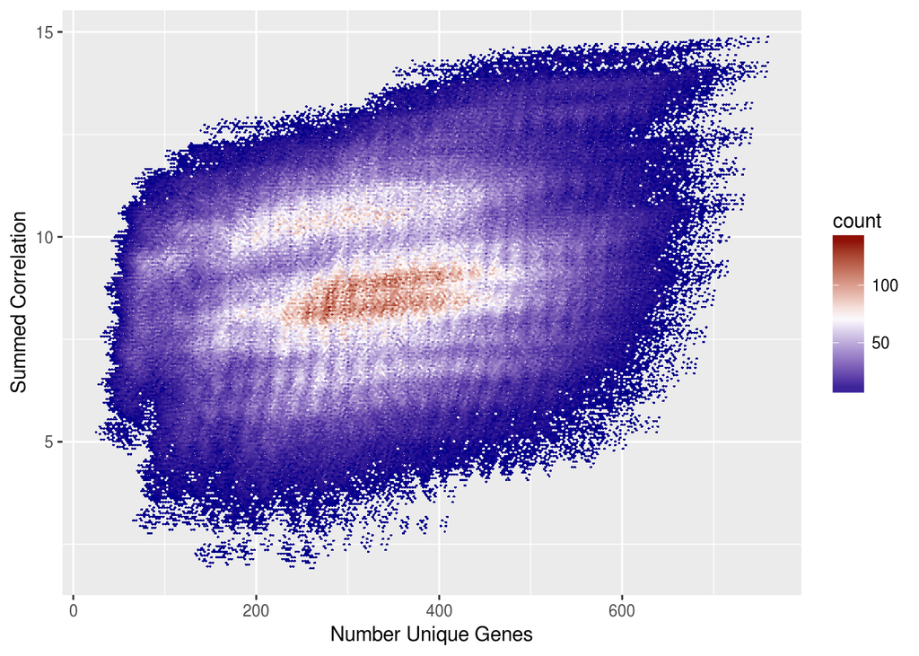

### 1 to 50 genes

[1] “The best pathway list between 1 and 50 is 50 with a summed correlation of 10.603370003064”

| Pathway | Genes | Protein | ICBP.cor | TCGA.cor | ICBP.diff | TCGA.diff |
| --- | --- | --- | --- | --- | --- | --- |
| akt | 5 | Akt | 0.6168071 | -0.0511464 | 0.0411424 | -0.2432655 |
| akt | 5 | PDK1 | 0.6614509 | -0.0891008 | 0.0875369 | -0.3277670 |
| akt | 5 | PDK1_pS241 | 0.5944852 | 0.0165341 | 0.0595251 | -0.3207518 |
| bad | 15 | Akt | -0.0112704 | -0.0005623 | -0.4676660 | -0.1508035 |
| bad | 15 | PDK1 | 0.2478389 | 0.1888493 | -0.3567130 | -0.1238094 |
| bad | 15 | PDK1_pS241 | 0.2180764 | 0.2350648 | -0.2995951 | 0.0035171 |
| egfr | 10 | EGFR | 0.4975380 | 0.3548537 | 0.0271364 | -0.0017812 |
| egfr | 10 | EGFR_pY1068 | 0.4178794 | 0.0939790 | 0.0212277 | -0.0353075 |
| egfr | 10 | EGFR_pY1173 | NA | 0.1331719 | NA | -0.0220148 |
| her2 | 5 | HER2 | 0.9159645 | 0.3134173 | -0.0065653 | -0.0630429 |
| her2 | 5 | HER2_pY1248 | 0.9511982 | 0.3030885 | -0.0015319 | -0.0529551 |
| igf1r | 15 | IRS1 | NA | 0.3516127 | NA | 0.0278326 |
| igf1r | 15 | IGF1R | 0.3611993 | NA | 0.2755225 | NA |
| igf1r | 15 | PDK1 | 0.4725900 | 0.2677128 | -0.0967283 | -0.1030191 |
| igf1r | 15 | PDK1_pS241 | 0.4012474 | 0.3122586 | -0.1081081 | -0.0907584 |
| krasgv | 5 | EGFR | 0.1911588 | 0.1807791 | -0.2321917 | -0.3120602 |
| krasgv | 5 | EGFR_pY1068 | 0.1918153 | 0.0913609 | -0.1039501 | 0.0024104 |
| krasgv | 5 | EGFR_pY1173 | NA | 0.1050626 | NA | 0.0149734 |
| krasgv | 5 | MEK1 | NA | 0.0465197 | NA | -0.0692492 |
| raf | 10 | MEK1 | 0.0605099 | 0.0439229 | -0.2240945 | -0.2012081 |
| raf | 10 | PKC.alpha | 0.2918262 | 0.1146773 | -0.1748550 | -0.2812575 |
| raf | 10 | PKC.alpha_pS657 | 0.4067185 | 0.1042806 | -0.0553671 | -0.3105386 |

### 51 to 100 genes

[1] “The best pathway list between 51 and 100 is 100 with a summed correlation of 11.97655706205”

| Pathway | Genes | Protein | ICBP.cor | TCGA.cor | ICBP.diff | TCGA.diff |
| --- | --- | --- | --- | --- | --- | --- |
| akt | 20 | Akt | 0.5756647 | 0.1921191 | 0.0000000 | 0.0000000 |
| akt | 20 | PDK1 | 0.5739140 | 0.2386662 | 0.0000000 | 0.0000000 |
| akt | 20 | PDK1_pS241 | 0.5349601 | 0.3372859 | 0.0000000 | 0.0000000 |
| bad | 15 | Akt | -0.0112704 | -0.0005623 | -0.4676660 | -0.1508035 |
| bad | 15 | PDK1 | 0.2478389 | 0.1888493 | -0.3567130 | -0.1238094 |
| bad | 15 | PDK1_pS241 | 0.2180764 | 0.2350648 | -0.2995951 | 0.0035171 |
| egfr | 10 | EGFR | 0.4975380 | 0.3548537 | 0.0271364 | -0.0017812 |
| egfr | 10 | EGFR_pY1068 | 0.4178794 | 0.0939790 | 0.0212277 | -0.0353075 |
| egfr | 10 | EGFR_pY1173 | NA | 0.1331719 | NA | -0.0220148 |
| her2 | 5 | HER2 | 0.9159645 | 0.3134173 | -0.0065653 | -0.0630429 |
| her2 | 5 | HER2_pY1248 | 0.9511982 | 0.3030885 | -0.0015319 | -0.0529551 |
| igf1r | 15 | IRS1 | NA | 0.3516127 | NA | 0.0278326 |
| igf1r | 15 | IGF1R | 0.3611993 | NA | 0.2755225 | NA |
| igf1r | 15 | PDK1 | 0.4725900 | 0.2677128 | -0.0967283 | -0.1030191 |
| igf1r | 15 | PDK1_pS241 | 0.4012474 | 0.3122586 | -0.1081081 | -0.0907584 |
| krasgv | 5 | EGFR | 0.1911588 | 0.1807791 | -0.2321917 | -0.3120602 |
| krasgv | 5 | EGFR_pY1068 | 0.1918153 | 0.0913609 | -0.1039501 | 0.0024104 |
| krasgv | 5 | EGFR_pY1173 | NA | 0.1050626 | NA | 0.0149734 |
| krasgv | 5 | MEK1 | NA | 0.0465197 | NA | -0.0692492 |
| raf | 50 | MEK1 | 0.2358026 | 0.2397319 | -0.0488018 | -0.0053990 |
| raf | 50 | PKC.alpha | 0.1854689 | 0.3820730 | -0.2812124 | -0.0138618 |
| raf | 50 | PKC.alpha_pS657 | 0.2662217 | 0.3822444 | -0.1958639 | -0.0325748 |

### 101 - 150 genes

[1] “The best pathway list between 101 and 150 is 143 with a summed correlation of 12.7433068850486”

| Pathway | Genes | Protein | ICBP.cor | TCGA.cor | ICBP.diff | TCGA.diff |
| --- | --- | --- | --- | --- | --- | --- |
| akt | 20 | Akt | 0.5756647 | 0.1921191 | 0.0000000 | 0.0000000 |
| akt | 20 | PDK1 | 0.5739140 | 0.2386662 | 0.0000000 | 0.0000000 |
| akt | 20 | PDK1_pS241 | 0.5349601 | 0.3372859 | 0.0000000 | 0.0000000 |
| bad | 15 | Akt | -0.0112704 | -0.0005623 | -0.4676660 | -0.1508035 |
| bad | 15 | PDK1 | 0.2478389 | 0.1888493 | -0.3567130 | -0.1238094 |
| bad | 15 | PDK1_pS241 | 0.2180764 | 0.2350648 | -0.2995951 | 0.0035171 |
| egfr | 10 | EGFR | 0.4975380 | 0.3548537 | 0.0271364 | -0.0017812 |
| egfr | 10 | EGFR_pY1068 | 0.4178794 | 0.0939790 | 0.0212277 | -0.0353075 |
| egfr | 10 | EGFR_pY1173 | NA | 0.1331719 | NA | -0.0220148 |
| her2 | 10 | HER2 | 0.9225298 | 0.3764602 | 0.0000000 | 0.0000000 |
| her2 | 10 | HER2_pY1248 | 0.9527301 | 0.3560436 | 0.0000000 | 0.0000000 |
| igf1r | 15 | IRS1 | NA | 0.3516127 | NA | 0.0278326 |
| igf1r | 15 | IGF1R | 0.3611993 | NA | 0.2755225 | NA |
| igf1r | 15 | PDK1 | 0.4725900 | 0.2677128 | -0.0967283 | -0.1030191 |
| igf1r | 15 | PDK1_pS241 | 0.4012474 | 0.3122586 | -0.1081081 | -0.0907584 |
| krasgv | 75 | EGFR | 0.3894299 | 0.4769362 | -0.0339206 | -0.0159032 |
| krasgv | 75 | EGFR_pY1068 | 0.2972973 | 0.1037292 | 0.0015319 | 0.0147787 |
| krasgv | 75 | EGFR_pY1173 | NA | 0.1133842 | NA | 0.0232950 |
| krasgv | 75 | MEK1 | NA | 0.0685742 | NA | -0.0471946 |
| raf | 50 | MEK1 | 0.2358026 | 0.2397319 | -0.0488018 | -0.0053990 |
| raf | 50 | PKC.alpha | 0.1854689 | 0.3820730 | -0.2812124 | -0.0138618 |
| raf | 50 | PKC.alpha_pS657 | 0.2662217 | 0.3822444 | -0.1958639 | -0.0325748 |

### 151 - 200 genes

[1] “The best pathway list between 151 and 200 is 191 with a summed correlation of 12.9061405312698”

| Pathway | Genes | Protein | ICBP.cor | TCGA.cor | ICBP.diff | TCGA.diff |
| --- | --- | --- | --- | --- | --- | --- |
| akt | 20 | Akt | 0.5756647 | 0.1921191 | 0.0000000 | 0.0000000 |
| akt | 20 | PDK1 | 0.5739140 | 0.2386662 | 0.0000000 | 0.0000000 |
| akt | 20 | PDK1_pS241 | 0.5349601 | 0.3372859 | 0.0000000 | 0.0000000 |
| bad | 15 | Akt | -0.0112704 | -0.0005623 | -0.4676660 | -0.1508035 |
| bad | 15 | PDK1 | 0.2478389 | 0.1888493 | -0.3567130 | -0.1238094 |
| bad | 15 | PDK1_pS241 | 0.2180764 | 0.2350648 | -0.2995951 | 0.0035171 |
| egfr | 10 | EGFR | 0.4975380 | 0.3548537 | 0.0271364 | -0.0017812 |
| egfr | 10 | EGFR_pY1068 | 0.4178794 | 0.0939790 | 0.0212277 | -0.0353075 |
| egfr | 10 | EGFR_pY1173 | NA | 0.1331719 | NA | -0.0220148 |
| her2 | 10 | HER2 | 0.9225298 | 0.3764602 | 0.0000000 | 0.0000000 |
| her2 | 10 | HER2_pY1248 | 0.9527301 | 0.3560436 | 0.0000000 | 0.0000000 |
| igf1r | 50 | IRS1 | NA | 0.3221566 | NA | -0.0016235 |
| igf1r | 50 | IGF1R | 0.2003501 | NA | 0.1146734 | NA |
| igf1r | 50 | PDK1 | 0.5264252 | 0.3060018 | -0.0428931 | -0.0647301 |
| igf1r | 50 | PDK1_pS241 | 0.4717146 | 0.3654244 | -0.0376409 | -0.0375925 |
| krasgv | 75 | EGFR | 0.3894299 | 0.4769362 | -0.0339206 | -0.0159032 |
| krasgv | 75 | EGFR_pY1068 | 0.2972973 | 0.1037292 | 0.0015319 | 0.0147787 |
| krasgv | 75 | EGFR_pY1173 | NA | 0.1133842 | NA | 0.0232950 |
| krasgv | 75 | MEK1 | NA | 0.0685742 | NA | -0.0471946 |
| raf | 75 | MEK1 | 0.3762994 | 0.0773367 | 0.0916949 | -0.1677942 |
| raf | 75 | PKC.alpha | 0.3202757 | 0.3435776 | -0.1464055 | -0.0523572 |
| raf | 75 | PKC.alpha_pS657 | 0.3780501 | 0.3333846 | -0.0840355 | -0.0814347 |

### 201 - 250 genes

[1] “The best pathway list between 201 and 250 is 231 with a summed correlation of 13.0460747375431”

| Pathway | Genes | Protein | ICBP.cor | TCGA.cor | ICBP.diff | TCGA.diff |
| --- | --- | --- | --- | --- | --- | --- |
| akt | 20 | Akt | 0.5756647 | 0.1921191 | 0.0000000 | 0.0000000 |
| akt | 20 | PDK1 | 0.5739140 | 0.2386662 | 0.0000000 | 0.0000000 |
| akt | 20 | PDK1_pS241 | 0.5349601 | 0.3372859 | 0.0000000 | 0.0000000 |
| bad | 15 | Akt | -0.0112704 | -0.0005623 | -0.4676660 | -0.1508035 |
| bad | 15 | PDK1 | 0.2478389 | 0.1888493 | -0.3567130 | -0.1238094 |
| bad | 15 | PDK1_pS241 | 0.2180764 | 0.2350648 | -0.2995951 | 0.0035171 |
| egfr | 10 | EGFR | 0.4975380 | 0.3548537 | 0.0271364 | -0.0017812 |
| egfr | 10 | EGFR_pY1068 | 0.4178794 | 0.0939790 | 0.0212277 | -0.0353075 |
| egfr | 10 | EGFR_pY1173 | NA | 0.1331719 | NA | -0.0220148 |
| her2 | 10 | HER2 | 0.9225298 | 0.3764602 | 0.0000000 | 0.0000000 |
| her2 | 10 | HER2_pY1248 | 0.9527301 | 0.3560436 | 0.0000000 | 0.0000000 |
| igf1r | 15 | IRS1 | NA | 0.3516127 | NA | 0.0278326 |
| igf1r | 15 | IGF1R | 0.3611993 | NA | 0.2755225 | NA |
| igf1r | 15 | PDK1 | 0.4725900 | 0.2677128 | -0.0967283 | -0.1030191 |
| igf1r | 15 | PDK1_pS241 | 0.4012474 | 0.3122586 | -0.1081081 | -0.0907584 |
| krasgv | 75 | EGFR | 0.3894299 | 0.4769362 | -0.0339206 | -0.0159032 |
| krasgv | 75 | EGFR_pY1068 | 0.2972973 | 0.1037292 | 0.0015319 | 0.0147787 |
| krasgv | 75 | EGFR_pY1173 | NA | 0.1133842 | NA | 0.0232950 |
| krasgv | 75 | MEK1 | NA | 0.0685742 | NA | -0.0471946 |
| raf | 150 | MEK1 | 0.3524456 | 0.1054433 | 0.0678411 | -0.1396876 |
| raf | 150 | PKC.alpha | 0.3990590 | 0.3582092 | -0.0676223 | -0.0377256 |
| raf | 150 | PKC.alpha_pS657 | 0.4299157 | 0.3492376 | -0.0321698 | -0.0655817 |

### 251 - 300 genes

[1] “The best pathway list between 251 and 300 is 283 with a summed correlation of 13.2019744927346”

| Pathway | Genes | Protein | ICBP.cor | TCGA.cor | ICBP.diff | TCGA.diff |
| --- | --- | --- | --- | --- | --- | --- |
| akt | 20 | Akt | 0.5756647 | 0.1921191 | 0.0000000 | 0.0000000 |
| akt | 20 | PDK1 | 0.5739140 | 0.2386662 | 0.0000000 | 0.0000000 |
| akt | 20 | PDK1_pS241 | 0.5349601 | 0.3372859 | 0.0000000 | 0.0000000 |
| bad | 15 | Akt | -0.0112704 | -0.0005623 | -0.4676660 | -0.1508035 |
| bad | 15 | PDK1 | 0.2478389 | 0.1888493 | -0.3567130 | -0.1238094 |
| bad | 15 | PDK1_pS241 | 0.2180764 | 0.2350648 | -0.2995951 | 0.0035171 |
| egfr | 10 | EGFR | 0.4975380 | 0.3548537 | 0.0271364 | -0.0017812 |
| egfr | 10 | EGFR_pY1068 | 0.4178794 | 0.0939790 | 0.0212277 | -0.0353075 |
| egfr | 10 | EGFR_pY1173 | NA | 0.1331719 | NA | -0.0220148 |
| her2 | 10 | HER2 | 0.9225298 | 0.3764602 | 0.0000000 | 0.0000000 |
| her2 | 10 | HER2_pY1248 | 0.9527301 | 0.3560436 | 0.0000000 | 0.0000000 |
| igf1r | 50 | IRS1 | NA | 0.3221566 | NA | -0.0016235 |
| igf1r | 50 | IGF1R | 0.2003501 | NA | 0.1146734 | NA |
| igf1r | 50 | PDK1 | 0.5264252 | 0.3060018 | -0.0428931 | -0.0647301 |
| igf1r | 50 | PDK1_pS241 | 0.4717146 | 0.3654244 | -0.0376409 | -0.0375925 |
| krasgv | 75 | EGFR | 0.3894299 | 0.4769362 | -0.0339206 | -0.0159032 |
| krasgv | 75 | EGFR_pY1068 | 0.2972973 | 0.1037292 | 0.0015319 | 0.0147787 |
| krasgv | 75 | EGFR_pY1173 | NA | 0.1133842 | NA | 0.0232950 |
| krasgv | 75 | MEK1 | NA | 0.0685742 | NA | -0.0471946 |
| raf | 175 | MEK1 | 0.3474122 | 0.0943705 | 0.0628077 | -0.1507605 |
| raf | 175 | PKC.alpha | 0.4802495 | 0.3556985 | 0.0135682 | -0.0402362 |
| raf | 175 | PKC.alpha_pS657 | 0.5025714 | 0.3444559 | 0.0404858 | -0.0703633 |

### 301 - 400 genes

[1] “The best pathway list between 301 and 400 is 395 with a summed correlation of 14.3012104710659”

| Pathway | Genes | Protein | ICBP.cor | TCGA.cor | ICBP.diff | TCGA.diff |
| --- | --- | --- | --- | --- | --- | --- |
| akt | 20 | Akt | 0.5756647 | 0.1921191 | 0.0000000 | 0.0000000 |
| akt | 20 | PDK1 | 0.5739140 | 0.2386662 | 0.0000000 | 0.0000000 |
| akt | 20 | PDK1_pS241 | 0.5349601 | 0.3372859 | 0.0000000 | 0.0000000 |
| bad | 250 | Akt | 0.4563957 | 0.1502412 | 0.0000000 | 0.0000000 |
| bad | 250 | PDK1 | 0.6045519 | 0.3126587 | 0.0000000 | 0.0000000 |
| bad | 250 | PDK1_pS241 | 0.5176715 | 0.2315477 | 0.0000000 | 0.0000000 |
| egfr | 10 | EGFR | 0.4975380 | 0.3548537 | 0.0271364 | -0.0017812 |
| egfr | 10 | EGFR_pY1068 | 0.4178794 | 0.0939790 | 0.0212277 | -0.0353075 |
| egfr | 10 | EGFR_pY1173 | NA | 0.1331719 | NA | -0.0220148 |
| her2 | 10 | HER2 | 0.9225298 | 0.3764602 | 0.0000000 | 0.0000000 |
| her2 | 10 | HER2_pY1248 | 0.9527301 | 0.3560436 | 0.0000000 | 0.0000000 |
| igf1r | 50 | IRS1 | NA | 0.3221566 | NA | -0.0016235 |
| igf1r | 50 | IGF1R | 0.2003501 | NA | 0.1146734 | NA |
| igf1r | 50 | PDK1 | 0.5264252 | 0.3060018 | -0.0428931 | -0.0647301 |
| igf1r | 50 | PDK1_pS241 | 0.4717146 | 0.3654244 | -0.0376409 | -0.0375925 |
| krasgv | 75 | EGFR | 0.3894299 | 0.4769362 | -0.0339206 | -0.0159032 |
| krasgv | 75 | EGFR_pY1068 | 0.2972973 | 0.1037292 | 0.0015319 | 0.0147787 |
| krasgv | 75 | EGFR_pY1173 | NA | 0.1133842 | NA | 0.0232950 |
| krasgv | 75 | MEK1 | NA | 0.0685742 | NA | -0.0471946 |
| raf | 75 | MEK1 | 0.3762994 | 0.0773367 | 0.0916949 | -0.1677942 |
| raf | 75 | PKC.alpha | 0.3202757 | 0.3435776 | -0.1464055 | -0.0523572 |
| raf | 75 | PKC.alpha_pS657 | 0.3780501 | 0.3333846 | -0.0840355 | -0.0814347 |

### 401 - 500 genes

[1] “The best pathway list between 401 and 500 is 499 with a summed correlation of 14.6012094459031”

| Pathway | Genes | Protein | ICBP.cor | TCGA.cor | ICBP.diff | TCGA.diff |
| --- | --- | --- | --- | --- | --- | --- |
| akt | 20 | Akt | 0.5756647 | 0.1921191 | 0.0000000 | 0.0000000 |
| akt | 20 | PDK1 | 0.5739140 | 0.2386662 | 0.0000000 | 0.0000000 |
| akt | 20 | PDK1_pS241 | 0.5349601 | 0.3372859 | 0.0000000 | 0.0000000 |
| bad | 250 | Akt | 0.4563957 | 0.1502412 | 0.0000000 | 0.0000000 |
| bad | 250 | PDK1 | 0.6045519 | 0.3126587 | 0.0000000 | 0.0000000 |
| bad | 250 | PDK1_pS241 | 0.5176715 | 0.2315477 | 0.0000000 | 0.0000000 |
| egfr | 10 | EGFR | 0.4975380 | 0.3548537 | 0.0271364 | -0.0017812 |
| egfr | 10 | EGFR_pY1068 | 0.4178794 | 0.0939790 | 0.0212277 | -0.0353075 |
| egfr | 10 | EGFR_pY1173 | NA | 0.1331719 | NA | -0.0220148 |
| her2 | 10 | HER2 | 0.9225298 | 0.3764602 | 0.0000000 | 0.0000000 |
| her2 | 10 | HER2_pY1248 | 0.9527301 | 0.3560436 | 0.0000000 | 0.0000000 |
| igf1r | 15 | IRS1 | NA | 0.3516127 | NA | 0.0278326 |
| igf1r | 15 | IGF1R | 0.3611993 | NA | 0.2755225 | NA |
| igf1r | 15 | PDK1 | 0.4725900 | 0.2677128 | -0.0967283 | -0.1030191 |
| igf1r | 15 | PDK1_pS241 | 0.4012474 | 0.3122586 | -0.1081081 | -0.0907584 |
| krasgv | 150 | EGFR | 0.3988401 | 0.4879869 | -0.0245103 | -0.0048524 |
| krasgv | 150 | EGFR_pY1068 | 0.3108655 | 0.0935103 | 0.0151001 | 0.0045598 |
| krasgv | 150 | EGFR_pY1173 | NA | 0.0887196 | NA | -0.0013696 |
| krasgv | 150 | MEK1 | NA | 0.0990456 | NA | -0.0167232 |
| raf | 175 | MEK1 | 0.3474122 | 0.0943705 | 0.0628077 | -0.1507605 |
| raf | 175 | PKC.alpha | 0.4802495 | 0.3556985 | 0.0135682 | -0.0402362 |
| raf | 175 | PKC.alpha_pS657 | 0.5025714 | 0.3444559 | 0.0404858 | -0.0703633 |

### 501 - 600 genes

[1] “The best pathway list between 501 and 600 is 594 with a summed correlation of 14.7242639056947”

| Pathway | Genes | Protein | ICBP.cor | TCGA.cor | ICBP.diff | TCGA.diff |
| --- | --- | --- | --- | --- | --- | --- |
| akt | 20 | Akt | 0.5756647 | 0.1921191 | 0.0000000 | 0.0000000 |
| akt | 20 | PDK1 | 0.5739140 | 0.2386662 | 0.0000000 | 0.0000000 |
| akt | 20 | PDK1_pS241 | 0.5349601 | 0.3372859 | 0.0000000 | 0.0000000 |
| bad | 250 | Akt | 0.4563957 | 0.1502412 | 0.0000000 | 0.0000000 |
| bad | 250 | PDK1 | 0.6045519 | 0.3126587 | 0.0000000 | 0.0000000 |
| bad | 250 | PDK1_pS241 | 0.5176715 | 0.2315477 | 0.0000000 | 0.0000000 |
| egfr | 10 | EGFR | 0.4975380 | 0.3548537 | 0.0271364 | -0.0017812 |
| egfr | 10 | EGFR_pY1068 | 0.4178794 | 0.0939790 | 0.0212277 | -0.0353075 |
| egfr | 10 | EGFR_pY1173 | NA | 0.1331719 | NA | -0.0220148 |
| her2 | 10 | HER2 | 0.9225298 | 0.3764602 | 0.0000000 | 0.0000000 |
| her2 | 10 | HER2_pY1248 | 0.9527301 | 0.3560436 | 0.0000000 | 0.0000000 |
| igf1r | 100 | IRS1 | NA | 0.3237801 | NA | 0.0000000 |
| igf1r | 100 | IGF1R | 0.0856768 | NA | 0.0000000 | NA |
| igf1r | 100 | PDK1 | 0.5693183 | 0.3707319 | 0.0000000 | 0.0000000 |
| igf1r | 100 | PDK1_pS241 | 0.5093555 | 0.4030169 | 0.0000000 | 0.0000000 |
| krasgv | 200 | EGFR | 0.4233505 | 0.4928393 | 0.0000000 | 0.0000000 |
| krasgv | 200 | EGFR_pY1068 | 0.2957654 | 0.0889505 | 0.0000000 | 0.0000000 |
| krasgv | 200 | EGFR_pY1173 | NA | 0.0900892 | NA | 0.0000000 |
| krasgv | 200 | MEK1 | NA | 0.1157688 | NA | 0.0000000 |
| raf | 175 | MEK1 | 0.3474122 | 0.0943705 | 0.0628077 | -0.1507605 |
| raf | 175 | PKC.alpha | 0.4802495 | 0.3556985 | 0.0135682 | -0.0402362 |
| raf | 175 | PKC.alpha_pS657 | 0.5025714 | 0.3444559 | 0.0404858 | -0.0703633 |

### 601 - 700 genes

[1] “The best pathway list between 601 and 700 is 676 with a summed correlation of 14.8113494290456”

| Pathway | Genes | Protein | ICBP.cor | TCGA.cor | ICBP.diff | TCGA.diff |
| --- | --- | --- | --- | --- | --- | --- |
| akt | 20 | Akt | 0.5756647 | 0.1921191 | 0.0000000 | 0.0000000 |
| akt | 20 | PDK1 | 0.5739140 | 0.2386662 | 0.0000000 | 0.0000000 |
| akt | 20 | PDK1_pS241 | 0.5349601 | 0.3372859 | 0.0000000 | 0.0000000 |
| bad | 250 | Akt | 0.4563957 | 0.1502412 | 0.0000000 | 0.0000000 |
| bad | 250 | PDK1 | 0.6045519 | 0.3126587 | 0.0000000 | 0.0000000 |
| bad | 250 | PDK1_pS241 | 0.5176715 | 0.2315477 | 0.0000000 | 0.0000000 |
| egfr | 10 | EGFR | 0.4975380 | 0.3548537 | 0.0271364 | -0.0017812 |
| egfr | 10 | EGFR_pY1068 | 0.4178794 | 0.0939790 | 0.0212277 | -0.0353075 |
| egfr | 10 | EGFR_pY1173 | NA | 0.1331719 | NA | -0.0220148 |
| her2 | 10 | HER2 | 0.9225298 | 0.3764602 | 0.0000000 | 0.0000000 |
| her2 | 10 | HER2_pY1248 | 0.9527301 | 0.3560436 | 0.0000000 | 0.0000000 |
| igf1r | 100 | IRS1 | NA | 0.3237801 | NA | 0.0000000 |
| igf1r | 100 | IGF1R | 0.0856768 | NA | 0.0000000 | NA |
| igf1r | 100 | PDK1 | 0.5693183 | 0.3707319 | 0.0000000 | 0.0000000 |
| igf1r | 100 | PDK1_pS241 | 0.5093555 | 0.4030169 | 0.0000000 | 0.0000000 |
| krasgv | 75 | EGFR | 0.3894299 | 0.4769362 | -0.0339206 | -0.0159032 |
| krasgv | 75 | EGFR_pY1068 | 0.2972973 | 0.1037292 | 0.0015319 | 0.0147787 |
| krasgv | 75 | EGFR_pY1173 | NA | 0.1133842 | NA | 0.0232950 |
| krasgv | 75 | MEK1 | NA | 0.0685742 | NA | -0.0471946 |
| raf | 350 | MEK1 | 0.2846044 | 0.2451310 | 0.0000000 | 0.0000000 |
| raf | 350 | PKC.alpha | 0.4666813 | 0.3959348 | 0.0000000 | 0.0000000 |
| raf | 350 | PKC.alpha_pS657 | 0.4620856 | 0.4148193 | 0.0000000 | 0.0000000 |

## Reduce by Average Correlation

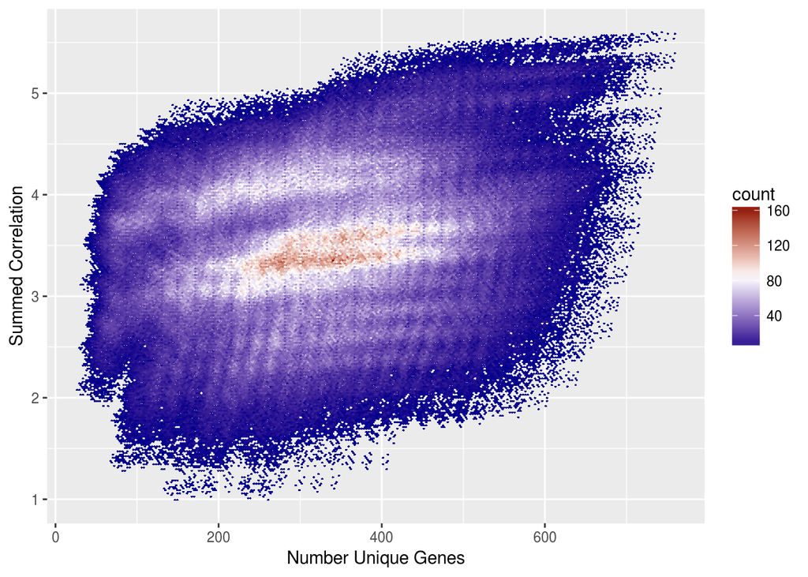

### 1 to 50 genes

[1] “The best pathway list between 1 and 50 is 50 with a summed correlation of 4.12948982665785”

| Pathway | Genes | Protein | ICBP.cor | TCGA.cor | ICBP.diff | TCGA.diff |
| --- | --- | --- | --- | --- | --- | --- |
| akt | 5 | Akt | 0.6168071 | -0.0511464 | 0.0411424 | -0.2432655 |
| akt | 5 | PDK1 | 0.6614509 | -0.0891008 | 0.0875369 | -0.3277670 |
| akt | 5 | PDK1_pS241 | 0.5944852 | 0.0165341 | 0.0595251 | -0.3207518 |
| bad | 15 | Akt | -0.0112704 | -0.0005623 | -0.4676660 | -0.1508035 |
| bad | 15 | PDK1 | 0.2478389 | 0.1888493 | -0.3567130 | -0.1238094 |
| bad | 15 | PDK1_pS241 | 0.2180764 | 0.2350648 | -0.2995951 | 0.0035171 |
| egfr | 10 | EGFR | 0.4975380 | 0.3548537 | 0.0271364 | -0.0017812 |
| egfr | 10 | EGFR_pY1068 | 0.4178794 | 0.0939790 | 0.0212277 | -0.0353075 |
| egfr | 10 | EGFR_pY1173 | NA | 0.1331719 | NA | -0.0220148 |
| her2 | 5 | HER2 | 0.9159645 | 0.3134173 | -0.0065653 | -0.0630429 |
| her2 | 5 | HER2_pY1248 | 0.9511982 | 0.3030885 | -0.0015319 | -0.0529551 |
| igf1r | 15 | IRS1 | NA | 0.3516127 | NA | 0.0278326 |
| igf1r | 15 | IGF1R | 0.3611993 | NA | 0.2755225 | NA |
| igf1r | 15 | PDK1 | 0.4725900 | 0.2677128 | -0.0967283 | -0.1030191 |
| igf1r | 15 | PDK1_pS241 | 0.4012474 | 0.3122586 | -0.1081081 | -0.0907584 |
| krasgv | 5 | EGFR | 0.1911588 | 0.1807791 | -0.2321917 | -0.3120602 |
| krasgv | 5 | EGFR_pY1068 | 0.1918153 | 0.0913609 | -0.1039501 | 0.0024104 |
| krasgv | 5 | EGFR_pY1173 | NA | 0.1050626 | NA | 0.0149734 |
| krasgv | 5 | MEK1 | NA | 0.0465197 | NA | -0.0692492 |
| raf | 10 | MEK1 | 0.0605099 | 0.0439229 | -0.2240945 | -0.2012081 |
| raf | 10 | PKC.alpha | 0.2918262 | 0.1146773 | -0.1748550 | -0.2812575 |
| raf | 10 | PKC.alpha_pS657 | 0.4067185 | 0.1042806 | -0.0553671 | -0.3105386 |

### 51 to 100 genes

[1] “The best pathway list between 51 and 100 is 100 with a summed correlation of 4.58721884631986”

| Pathway | Genes | Protein | ICBP.cor | TCGA.cor | ICBP.diff | TCGA.diff |
| --- | --- | --- | --- | --- | --- | --- |
| akt | 20 | Akt | 0.5756647 | 0.1921191 | 0.0000000 | 0.0000000 |
| akt | 20 | PDK1 | 0.5739140 | 0.2386662 | 0.0000000 | 0.0000000 |
| akt | 20 | PDK1_pS241 | 0.5349601 | 0.3372859 | 0.0000000 | 0.0000000 |
| bad | 15 | Akt | -0.0112704 | -0.0005623 | -0.4676660 | -0.1508035 |
| bad | 15 | PDK1 | 0.2478389 | 0.1888493 | -0.3567130 | -0.1238094 |
| bad | 15 | PDK1_pS241 | 0.2180764 | 0.2350648 | -0.2995951 | 0.0035171 |
| egfr | 10 | EGFR | 0.4975380 | 0.3548537 | 0.0271364 | -0.0017812 |
| egfr | 10 | EGFR_pY1068 | 0.4178794 | 0.0939790 | 0.0212277 | -0.0353075 |
| egfr | 10 | EGFR_pY1173 | NA | 0.1331719 | NA | -0.0220148 |
| her2 | 5 | HER2 | 0.9159645 | 0.3134173 | -0.0065653 | -0.0630429 |
| her2 | 5 | HER2_pY1248 | 0.9511982 | 0.3030885 | -0.0015319 | -0.0529551 |
| igf1r | 15 | IRS1 | NA | 0.3516127 | NA | 0.0278326 |
| igf1r | 15 | IGF1R | 0.3611993 | NA | 0.2755225 | NA |
| igf1r | 15 | PDK1 | 0.4725900 | 0.2677128 | -0.0967283 | -0.1030191 |
| igf1r | 15 | PDK1_pS241 | 0.4012474 | 0.3122586 | -0.1081081 | -0.0907584 |
| krasgv | 5 | EGFR | 0.1911588 | 0.1807791 | -0.2321917 | -0.3120602 |
| krasgv | 5 | EGFR_pY1068 | 0.1918153 | 0.0913609 | -0.1039501 | 0.0024104 |
| krasgv | 5 | EGFR_pY1173 | NA | 0.1050626 | NA | 0.0149734 |
| krasgv | 5 | MEK1 | NA | 0.0465197 | NA | -0.0692492 |
| raf | 50 | MEK1 | 0.2358026 | 0.2397319 | -0.0488018 | -0.0053990 |
| raf | 50 | PKC.alpha | 0.1854689 | 0.3820730 | -0.2812124 | -0.0138618 |
| raf | 50 | PKC.alpha_pS657 | 0.2662217 | 0.3822444 | -0.1958639 | -0.0325748 |

### 101 - 150 genes

[1] “The best pathway list between 101 and 150 is 143 with a summed correlation of 4.88586837997998”

| Pathway | Genes | Protein | ICBP.cor | TCGA.cor | ICBP.diff | TCGA.diff |
| --- | --- | --- | --- | --- | --- | --- |
| akt | 20 | Akt | 0.5756647 | 0.1921191 | 0.0000000 | 0.0000000 |
| akt | 20 | PDK1 | 0.5739140 | 0.2386662 | 0.0000000 | 0.0000000 |
| akt | 20 | PDK1_pS241 | 0.5349601 | 0.3372859 | 0.0000000 | 0.0000000 |
| bad | 15 | Akt | -0.0112704 | -0.0005623 | -0.4676660 | -0.1508035 |
| bad | 15 | PDK1 | 0.2478389 | 0.1888493 | -0.3567130 | -0.1238094 |
| bad | 15 | PDK1_pS241 | 0.2180764 | 0.2350648 | -0.2995951 | 0.0035171 |
| egfr | 10 | EGFR | 0.4975380 | 0.3548537 | 0.0271364 | -0.0017812 |
| egfr | 10 | EGFR_pY1068 | 0.4178794 | 0.0939790 | 0.0212277 | -0.0353075 |
| egfr | 10 | EGFR_pY1173 | NA | 0.1331719 | NA | -0.0220148 |
| her2 | 10 | HER2 | 0.9225298 | 0.3764602 | 0.0000000 | 0.0000000 |
| her2 | 10 | HER2_pY1248 | 0.9527301 | 0.3560436 | 0.0000000 | 0.0000000 |
| igf1r | 15 | IRS1 | NA | 0.3516127 | NA | 0.0278326 |
| igf1r | 15 | IGF1R | 0.3611993 | NA | 0.2755225 | NA |
| igf1r | 15 | PDK1 | 0.4725900 | 0.2677128 | -0.0967283 | -0.1030191 |
| igf1r | 15 | PDK1_pS241 | 0.4012474 | 0.3122586 | -0.1081081 | -0.0907584 |
| krasgv | 75 | EGFR | 0.3894299 | 0.4769362 | -0.0339206 | -0.0159032 |
| krasgv | 75 | EGFR_pY1068 | 0.2972973 | 0.1037292 | 0.0015319 | 0.0147787 |
| krasgv | 75 | EGFR_pY1173 | NA | 0.1133842 | NA | 0.0232950 |
| krasgv | 75 | MEK1 | NA | 0.0685742 | NA | -0.0471946 |
| raf | 50 | MEK1 | 0.2358026 | 0.2397319 | -0.0488018 | -0.0053990 |
| raf | 50 | PKC.alpha | 0.1854689 | 0.3820730 | -0.2812124 | -0.0138618 |
| raf | 50 | PKC.alpha_pS657 | 0.2662217 | 0.3822444 | -0.1958639 | -0.0325748 |

### 151 - 200 genes

[1] “The best pathway list between 151 and 200 is 191 with a summed correlation of 4.94014626205374”

| Pathway | Genes | Protein | ICBP.cor | TCGA.cor | ICBP.diff | TCGA.diff |
| --- | --- | --- | --- | --- | --- | --- |
| akt | 20 | Akt | 0.5756647 | 0.1921191 | 0.0000000 | 0.0000000 |
| akt | 20 | PDK1 | 0.5739140 | 0.2386662 | 0.0000000 | 0.0000000 |
| akt | 20 | PDK1_pS241 | 0.5349601 | 0.3372859 | 0.0000000 | 0.0000000 |
| bad | 15 | Akt | -0.0112704 | -0.0005623 | -0.4676660 | -0.1508035 |
| bad | 15 | PDK1 | 0.2478389 | 0.1888493 | -0.3567130 | -0.1238094 |
| bad | 15 | PDK1_pS241 | 0.2180764 | 0.2350648 | -0.2995951 | 0.0035171 |
| egfr | 10 | EGFR | 0.4975380 | 0.3548537 | 0.0271364 | -0.0017812 |
| egfr | 10 | EGFR_pY1068 | 0.4178794 | 0.0939790 | 0.0212277 | -0.0353075 |
| egfr | 10 | EGFR_pY1173 | NA | 0.1331719 | NA | -0.0220148 |
| her2 | 10 | HER2 | 0.9225298 | 0.3764602 | 0.0000000 | 0.0000000 |
| her2 | 10 | HER2_pY1248 | 0.9527301 | 0.3560436 | 0.0000000 | 0.0000000 |
| igf1r | 50 | IRS1 | NA | 0.3221566 | NA | -0.0016235 |
| igf1r | 50 | IGF1R | 0.2003501 | NA | 0.1146734 | NA |
| igf1r | 50 | PDK1 | 0.5264252 | 0.3060018 | -0.0428931 | -0.0647301 |
| igf1r | 50 | PDK1_pS241 | 0.4717146 | 0.3654244 | -0.0376409 | -0.0375925 |
| krasgv | 75 | EGFR | 0.3894299 | 0.4769362 | -0.0339206 | -0.0159032 |
| krasgv | 75 | EGFR_pY1068 | 0.2972973 | 0.1037292 | 0.0015319 | 0.0147787 |
| krasgv | 75 | EGFR_pY1173 | NA | 0.1133842 | NA | 0.0232950 |
| krasgv | 75 | MEK1 | NA | 0.0685742 | NA | -0.0471946 |
| raf | 75 | MEK1 | 0.3762994 | 0.0773367 | 0.0916949 | -0.1677942 |
| raf | 75 | PKC.alpha | 0.3202757 | 0.3435776 | -0.1464055 | -0.0523572 |
| raf | 75 | PKC.alpha_pS657 | 0.3780501 | 0.3333846 | -0.0840355 | -0.0814347 |

### 201 - 250 genes

[1] “The best pathway list between 201 and 250 is 231 with a summed correlation of 4.98679099747817”

| Pathway | Genes | Protein | ICBP.cor | TCGA.cor | ICBP.diff | TCGA.diff |
| --- | --- | --- | --- | --- | --- | --- |
| akt | 20 | Akt | 0.5756647 | 0.1921191 | 0.0000000 | 0.0000000 |
| akt | 20 | PDK1 | 0.5739140 | 0.2386662 | 0.0000000 | 0.0000000 |
| akt | 20 | PDK1_pS241 | 0.5349601 | 0.3372859 | 0.0000000 | 0.0000000 |
| bad | 15 | Akt | -0.0112704 | -0.0005623 | -0.4676660 | -0.1508035 |
| bad | 15 | PDK1 | 0.2478389 | 0.1888493 | -0.3567130 | -0.1238094 |
| bad | 15 | PDK1_pS241 | 0.2180764 | 0.2350648 | -0.2995951 | 0.0035171 |
| egfr | 10 | EGFR | 0.4975380 | 0.3548537 | 0.0271364 | -0.0017812 |
| egfr | 10 | EGFR_pY1068 | 0.4178794 | 0.0939790 | 0.0212277 | -0.0353075 |
| egfr | 10 | EGFR_pY1173 | NA | 0.1331719 | NA | -0.0220148 |
| her2 | 10 | HER2 | 0.9225298 | 0.3764602 | 0.0000000 | 0.0000000 |
| her2 | 10 | HER2_pY1248 | 0.9527301 | 0.3560436 | 0.0000000 | 0.0000000 |
| igf1r | 15 | IRS1 | NA | 0.3516127 | NA | 0.0278326 |
| igf1r | 15 | IGF1R | 0.3611993 | NA | 0.2755225 | NA |
| igf1r | 15 | PDK1 | 0.4725900 | 0.2677128 | -0.0967283 | -0.1030191 |
| igf1r | 15 | PDK1_pS241 | 0.4012474 | 0.3122586 | -0.1081081 | -0.0907584 |
| krasgv | 75 | EGFR | 0.3894299 | 0.4769362 | -0.0339206 | -0.0159032 |
| krasgv | 75 | EGFR_pY1068 | 0.2972973 | 0.1037292 | 0.0015319 | 0.0147787 |
| krasgv | 75 | EGFR_pY1173 | NA | 0.1133842 | NA | 0.0232950 |
| krasgv | 75 | MEK1 | NA | 0.0685742 | NA | -0.0471946 |
| raf | 150 | MEK1 | 0.3524456 | 0.1054433 | 0.0678411 | -0.1396876 |
| raf | 150 | PKC.alpha | 0.3990590 | 0.3582092 | -0.0676223 | -0.0377256 |
| raf | 150 | PKC.alpha_pS657 | 0.4299157 | 0.3492376 | -0.0321698 | -0.0655817 |

### 251 - 300 genes

[1] “The best pathway list between 251 and 300 is 283 with a summed correlation of 5.03875758254198”

| Pathway | Genes | Protein | ICBP.cor | TCGA.cor | ICBP.diff | TCGA.diff |
| --- | --- | --- | --- | --- | --- | --- |
| akt | 20 | Akt | 0.5756647 | 0.1921191 | 0.0000000 | 0.0000000 |
| akt | 20 | PDK1 | 0.5739140 | 0.2386662 | 0.0000000 | 0.0000000 |
| akt | 20 | PDK1_pS241 | 0.5349601 | 0.3372859 | 0.0000000 | 0.0000000 |
| bad | 15 | Akt | -0.0112704 | -0.0005623 | -0.4676660 | -0.1508035 |
| bad | 15 | PDK1 | 0.2478389 | 0.1888493 | -0.3567130 | -0.1238094 |
| bad | 15 | PDK1_pS241 | 0.2180764 | 0.2350648 | -0.2995951 | 0.0035171 |
| egfr | 10 | EGFR | 0.4975380 | 0.3548537 | 0.0271364 | -0.0017812 |
| egfr | 10 | EGFR_pY1068 | 0.4178794 | 0.0939790 | 0.0212277 | -0.0353075 |
| egfr | 10 | EGFR_pY1173 | NA | 0.1331719 | NA | -0.0220148 |
| her2 | 10 | HER2 | 0.9225298 | 0.3764602 | 0.0000000 | 0.0000000 |
| her2 | 10 | HER2_pY1248 | 0.9527301 | 0.3560436 | 0.0000000 | 0.0000000 |
| igf1r | 50 | IRS1 | NA | 0.3221566 | NA | -0.0016235 |
| igf1r | 50 | IGF1R | 0.2003501 | NA | 0.1146734 | NA |
| igf1r | 50 | PDK1 | 0.5264252 | 0.3060018 | -0.0428931 | -0.0647301 |
| igf1r | 50 | PDK1_pS241 | 0.4717146 | 0.3654244 | -0.0376409 | -0.0375925 |
| krasgv | 75 | EGFR | 0.3894299 | 0.4769362 | -0.0339206 | -0.0159032 |
| krasgv | 75 | EGFR_pY1068 | 0.2972973 | 0.1037292 | 0.0015319 | 0.0147787 |
| krasgv | 75 | EGFR_pY1173 | NA | 0.1133842 | NA | 0.0232950 |
| krasgv | 75 | MEK1 | NA | 0.0685742 | NA | -0.0471946 |
| raf | 175 | MEK1 | 0.3474122 | 0.0943705 | 0.0628077 | -0.1507605 |
| raf | 175 | PKC.alpha | 0.4802495 | 0.3556985 | 0.0135682 | -0.0402362 |
| raf | 175 | PKC.alpha_pS657 | 0.5025714 | 0.3444559 | 0.0404858 | -0.0703633 |

### 301 - 400 genes

[1] “The best pathway list between 301 and 400 is 395 with a summed correlation of 5.4051695753191”

| Pathway | Genes | Protein | ICBP.cor | TCGA.cor | ICBP.diff | TCGA.diff |
| --- | --- | --- | --- | --- | --- | --- |
| akt | 20 | Akt | 0.5756647 | 0.1921191 | 0.0000000 | 0.0000000 |
| akt | 20 | PDK1 | 0.5739140 | 0.2386662 | 0.0000000 | 0.0000000 |
| akt | 20 | PDK1_pS241 | 0.5349601 | 0.3372859 | 0.0000000 | 0.0000000 |
| bad | 250 | Akt | 0.4563957 | 0.1502412 | 0.0000000 | 0.0000000 |
| bad | 250 | PDK1 | 0.6045519 | 0.3126587 | 0.0000000 | 0.0000000 |
| bad | 250 | PDK1_pS241 | 0.5176715 | 0.2315477 | 0.0000000 | 0.0000000 |
| egfr | 10 | EGFR | 0.4975380 | 0.3548537 | 0.0271364 | -0.0017812 |
| egfr | 10 | EGFR_pY1068 | 0.4178794 | 0.0939790 | 0.0212277 | -0.0353075 |
| egfr | 10 | EGFR_pY1173 | NA | 0.1331719 | NA | -0.0220148 |
| her2 | 10 | HER2 | 0.9225298 | 0.3764602 | 0.0000000 | 0.0000000 |
| her2 | 10 | HER2_pY1248 | 0.9527301 | 0.3560436 | 0.0000000 | 0.0000000 |
| igf1r | 50 | IRS1 | NA | 0.3221566 | NA | -0.0016235 |
| igf1r | 50 | IGF1R | 0.2003501 | NA | 0.1146734 | NA |
| igf1r | 50 | PDK1 | 0.5264252 | 0.3060018 | -0.0428931 | -0.0647301 |
| igf1r | 50 | PDK1_pS241 | 0.4717146 | 0.3654244 | -0.0376409 | -0.0375925 |
| krasgv | 75 | EGFR | 0.3894299 | 0.4769362 | -0.0339206 | -0.0159032 |
| krasgv | 75 | EGFR_pY1068 | 0.2972973 | 0.1037292 | 0.0015319 | 0.0147787 |
| krasgv | 75 | EGFR_pY1173 | NA | 0.1133842 | NA | 0.0232950 |
| krasgv | 75 | MEK1 | NA | 0.0685742 | NA | -0.0471946 |
| raf | 75 | MEK1 | 0.3762994 | 0.0773367 | 0.0916949 | -0.1677942 |
| raf | 75 | PKC.alpha | 0.3202757 | 0.3435776 | -0.1464055 | -0.0523572 |
| raf | 75 | PKC.alpha_pS657 | 0.3780501 | 0.3333846 | -0.0840355 | -0.0814347 |

### 401 - 500 genes

[1] “The best pathway list between 401 and 500 is 499 with a summed correlation of 5.50844575390585”

| Pathway | Genes | Protein | ICBP.cor | TCGA.cor | ICBP.diff | TCGA.diff |
| --- | --- | --- | --- | --- | --- | --- |
| akt | 20 | Akt | 0.5756647 | 0.1921191 | 0.0000000 | 0.0000000 |
| akt | 20 | PDK1 | 0.5739140 | 0.2386662 | 0.0000000 | 0.0000000 |
| akt | 20 | PDK1_pS241 | 0.5349601 | 0.3372859 | 0.0000000 | 0.0000000 |
| bad | 250 | Akt | 0.4563957 | 0.1502412 | 0.0000000 | 0.0000000 |
| bad | 250 | PDK1 | 0.6045519 | 0.3126587 | 0.0000000 | 0.0000000 |
| bad | 250 | PDK1_pS241 | 0.5176715 | 0.2315477 | 0.0000000 | 0.0000000 |
| egfr | 10 | EGFR | 0.4975380 | 0.3548537 | 0.0271364 | -0.0017812 |
| egfr | 10 | EGFR_pY1068 | 0.4178794 | 0.0939790 | 0.0212277 | -0.0353075 |
| egfr | 10 | EGFR_pY1173 | NA | 0.1331719 | NA | -0.0220148 |
| her2 | 10 | HER2 | 0.9225298 | 0.3764602 | 0.0000000 | 0.0000000 |
| her2 | 10 | HER2_pY1248 | 0.9527301 | 0.3560436 | 0.0000000 | 0.0000000 |
| igf1r | 15 | IRS1 | NA | 0.3516127 | NA | 0.0278326 |
| igf1r | 15 | IGF1R | 0.3611993 | NA | 0.2755225 | NA |
| igf1r | 15 | PDK1 | 0.4725900 | 0.2677128 | -0.0967283 | -0.1030191 |
| igf1r | 15 | PDK1_pS241 | 0.4012474 | 0.3122586 | -0.1081081 | -0.0907584 |
| krasgv | 150 | EGFR | 0.3988401 | 0.4879869 | -0.0245103 | -0.0048524 |
| krasgv | 150 | EGFR_pY1068 | 0.3108655 | 0.0935103 | 0.0151001 | 0.0045598 |
| krasgv | 150 | EGFR_pY1173 | NA | 0.0887196 | NA | -0.0013696 |
| krasgv | 150 | MEK1 | NA | 0.0990456 | NA | -0.0167232 |
| raf | 175 | MEK1 | 0.3474122 | 0.0943705 | 0.0628077 | -0.1507605 |
| raf | 175 | PKC.alpha | 0.4802495 | 0.3556985 | 0.0135682 | -0.0402362 |
| raf | 175 | PKC.alpha_pS657 | 0.5025714 | 0.3444559 | 0.0404858 | -0.0703633 |

### 501 - 600 genes

[1] “The best pathway list between 501 and 600 is 594 with a summed correlation of 5.54950016105713”

| Pathway | Genes | Protein | ICBP.cor | TCGA.cor | ICBP.diff | TCGA.diff |
| --- | --- | --- | --- | --- | --- | --- |
| akt | 20 | Akt | 0.5756647 | 0.1921191 | 0.0000000 | 0.0000000 |
| akt | 20 | PDK1 | 0.5739140 | 0.2386662 | 0.0000000 | 0.0000000 |
| akt | 20 | PDK1_pS241 | 0.5349601 | 0.3372859 | 0.0000000 | 0.0000000 |
| bad | 250 | Akt | 0.4563957 | 0.1502412 | 0.0000000 | 0.0000000 |
| bad | 250 | PDK1 | 0.6045519 | 0.3126587 | 0.0000000 | 0.0000000 |
| bad | 250 | PDK1_pS241 | 0.5176715 | 0.2315477 | 0.0000000 | 0.0000000 |
| egfr | 10 | EGFR | 0.4975380 | 0.3548537 | 0.0271364 | -0.0017812 |
| egfr | 10 | EGFR_pY1068 | 0.4178794 | 0.0939790 | 0.0212277 | -0.0353075 |
| egfr | 10 | EGFR_pY1173 | NA | 0.1331719 | NA | -0.0220148 |
| her2 | 10 | HER2 | 0.9225298 | 0.3764602 | 0.0000000 | 0.0000000 |
| her2 | 10 | HER2_pY1248 | 0.9527301 | 0.3560436 | 0.0000000 | 0.0000000 |
| igf1r | 100 | IRS1 | NA | 0.3237801 | NA | 0.0000000 |
| igf1r | 100 | IGF1R | 0.0856768 | NA | 0.0000000 | NA |
| igf1r | 100 | PDK1 | 0.5693183 | 0.3707319 | 0.0000000 | 0.0000000 |
| igf1r | 100 | PDK1_pS241 | 0.5093555 | 0.4030169 | 0.0000000 | 0.0000000 |
| krasgv | 200 | EGFR | 0.4233505 | 0.4928393 | 0.0000000 | 0.0000000 |
| krasgv | 200 | EGFR_pY1068 | 0.2957654 | 0.0889505 | 0.0000000 | 0.0000000 |
| krasgv | 200 | EGFR_pY1173 | NA | 0.0900892 | NA | 0.0000000 |
| krasgv | 200 | MEK1 | NA | 0.1157688 | NA | 0.0000000 |
| raf | 175 | MEK1 | 0.3474122 | 0.0943705 | 0.0628077 | -0.1507605 |
| raf | 175 | PKC.alpha | 0.4802495 | 0.3556985 | 0.0135682 | -0.0402362 |
| raf | 175 | PKC.alpha_pS657 | 0.5025714 | 0.3444559 | 0.0404858 | -0.0703633 |

### 601 - 700 genes

[1] “The best pathway list between 601 and 700 is 676 with a summed correlation of 5.57521589464567”

| Pathway | Genes | Protein | ICBP.cor | TCGA.cor | ICBP.diff | TCGA.diff |
| --- | --- | --- | --- | --- | --- | --- |
| akt | 20 | Akt | 0.5756647 | 0.1921191 | 0.0000000 | 0.0000000 |
| akt | 20 | PDK1 | 0.5739140 | 0.2386662 | 0.0000000 | 0.0000000 |
| akt | 20 | PDK1_pS241 | 0.5349601 | 0.3372859 | 0.0000000 | 0.0000000 |
| bad | 250 | Akt | 0.4563957 | 0.1502412 | 0.0000000 | 0.0000000 |
| bad | 250 | PDK1 | 0.6045519 | 0.3126587 | 0.0000000 | 0.0000000 |
| bad | 250 | PDK1_pS241 | 0.5176715 | 0.2315477 | 0.0000000 | 0.0000000 |
| egfr | 10 | EGFR | 0.4975380 | 0.3548537 | 0.0271364 | -0.0017812 |
| egfr | 10 | EGFR_pY1068 | 0.4178794 | 0.0939790 | 0.0212277 | -0.0353075 |
| egfr | 10 | EGFR_pY1173 | NA | 0.1331719 | NA | -0.0220148 |
| her2 | 10 | HER2 | 0.9225298 | 0.3764602 | 0.0000000 | 0.0000000 |
| her2 | 10 | HER2_pY1248 | 0.9527301 | 0.3560436 | 0.0000000 | 0.0000000 |
| igf1r | 100 | IRS1 | NA | 0.3237801 | NA | 0.0000000 |
| igf1r | 100 | IGF1R | 0.0856768 | NA | 0.0000000 | NA |
| igf1r | 100 | PDK1 | 0.5693183 | 0.3707319 | 0.0000000 | 0.0000000 |
| igf1r | 100 | PDK1_pS241 | 0.5093555 | 0.4030169 | 0.0000000 | 0.0000000 |
| krasgv | 75 | EGFR | 0.3894299 | 0.4769362 | -0.0339206 | -0.0159032 |
| krasgv | 75 | EGFR_pY1068 | 0.2972973 | 0.1037292 | 0.0015319 | 0.0147787 |
| krasgv | 75 | EGFR_pY1173 | NA | 0.1133842 | NA | 0.0232950 |
| krasgv | 75 | MEK1 | NA | 0.0685742 | NA | -0.0471946 |
| raf | 350 | MEK1 | 0.2846044 | 0.2451310 | 0.0000000 | 0.0000000 |
| raf | 350 | PKC.alpha | 0.4666813 | 0.3959348 | 0.0000000 | 0.0000000 |
| raf | 350 | PKC.alpha_pS657 | 0.4620856 | 0.4148193 | 0.0000000 | 0.0000000 |

## Reduce by Average Correlation, TCGA Only

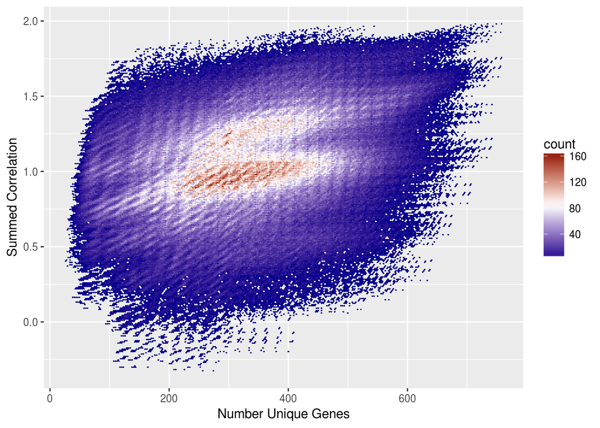

### 1 to 50 genes

[1] “The best pathway list between 1 and 50 is 49 with a summed correlation of 1.19460852796667”

| Pathway | Genes | Protein | ICBP.cor | TCGA.cor | ICBP.diff | TCGA.diff |
| --- | --- | --- | --- | --- | --- | --- |
| akt | 20 | Akt | 0.5756647 | 0.1921191 | 0.0000000 | 0.0000000 |
| akt | 20 | PDK1 | 0.5739140 | 0.2386662 | 0.0000000 | 0.0000000 |
| akt | 20 | PDK1_pS241 | 0.5349601 | 0.3372859 | 0.0000000 | 0.0000000 |
| bad | 5 | Akt | -0.2533100 | -0.0189997 | -0.7097057 | -0.1692409 |
| bad | 5 | PDK1 | 0.0110515 | -0.0067098 | -0.5935004 | -0.3193685 |
| bad | 5 | PDK1_pS241 | 0.0173980 | -0.0074620 | -0.5002736 | -0.2390097 |
| egfr | 10 | EGFR | 0.4975380 | 0.3548537 | 0.0271364 | -0.0017812 |
| egfr | 10 | EGFR_pY1068 | 0.4178794 | 0.0939790 | 0.0212277 | -0.0353075 |
| egfr | 10 | EGFR_pY1173 | NA | 0.1331719 | NA | -0.0220148 |
| her2 | 5 | HER2 | 0.9159645 | 0.3134173 | -0.0065653 | -0.0630429 |
| her2 | 5 | HER2_pY1248 | 0.9511982 | 0.3030885 | -0.0015319 | -0.0529551 |
| igf1r | 5 | IRS1 | NA | 0.3574676 | NA | 0.0336875 |
| igf1r | 5 | IGF1R | 0.5736952 | NA | 0.4880184 | NA |
| igf1r | 5 | PDK1 | 0.0635737 | 0.2108368 | -0.5057446 | -0.1598951 |
| igf1r | 5 | PDK1_pS241 | 0.0637925 | 0.1931854 | -0.4455630 | -0.2098315 |
| krasgv | 5 | EGFR | 0.1911588 | 0.1807791 | -0.2321917 | -0.3120602 |
| krasgv | 5 | EGFR_pY1068 | 0.1918153 | 0.0913609 | -0.1039501 | 0.0024104 |
| krasgv | 5 | EGFR_pY1173 | NA | 0.1050626 | NA | 0.0149734 |
| krasgv | 5 | MEK1 | NA | 0.0465197 | NA | -0.0692492 |
| raf | 10 | MEK1 | 0.0605099 | 0.0439229 | -0.2240945 | -0.2012081 |
| raf | 10 | PKC.alpha | 0.2918262 | 0.1146773 | -0.1748550 | -0.2812575 |
| raf | 10 | PKC.alpha_pS657 | 0.4067185 | 0.1042806 | -0.0553671 | -0.3105386 |

### 51 to 100 genes

[1] “The best pathway list between 51 and 100 is 99 with a summed correlation of 1.65386582383279”

| Pathway | Genes | Protein | ICBP.cor | TCGA.cor | ICBP.diff | TCGA.diff |
| --- | --- | --- | --- | --- | --- | --- |
| akt | 20 | Akt | 0.5756647 | 0.1921191 | 0.0000000 | 0.0000000 |
| akt | 20 | PDK1 | 0.5739140 | 0.2386662 | 0.0000000 | 0.0000000 |
| akt | 20 | PDK1_pS241 | 0.5349601 | 0.3372859 | 0.0000000 | 0.0000000 |
| bad | 15 | Akt | -0.0112704 | -0.0005623 | -0.4676660 | -0.1508035 |
| bad | 15 | PDK1 | 0.2478389 | 0.1888493 | -0.3567130 | -0.1238094 |
| bad | 15 | PDK1_pS241 | 0.2180764 | 0.2350648 | -0.2995951 | 0.0035171 |
| egfr | 10 | EGFR | 0.4975380 | 0.3548537 | 0.0271364 | -0.0017812 |
| egfr | 10 | EGFR_pY1068 | 0.4178794 | 0.0939790 | 0.0212277 | -0.0353075 |
| egfr | 10 | EGFR_pY1173 | NA | 0.1331719 | NA | -0.0220148 |
| her2 | 10 | HER2 | 0.9225298 | 0.3764602 | 0.0000000 | 0.0000000 |
| her2 | 10 | HER2_pY1248 | 0.9527301 | 0.3560436 | 0.0000000 | 0.0000000 |
| igf1r | 5 | IRS1 | NA | 0.3574676 | NA | 0.0336875 |
| igf1r | 5 | IGF1R | 0.5736952 | NA | 0.4880184 | NA |
| igf1r | 5 | PDK1 | 0.0635737 | 0.2108368 | -0.5057446 | -0.1598951 |
| igf1r | 5 | PDK1_pS241 | 0.0637925 | 0.1931854 | -0.4455630 | -0.2098315 |
| krasgv | 10 | EGFR | 0.1635846 | 0.1904112 | -0.2597658 | -0.3024282 |
| krasgv | 10 | EGFR_pY1068 | 0.1929095 | 0.0905787 | -0.1028559 | 0.0016282 |
| krasgv | 10 | EGFR_pY1173 | NA | 0.1022508 | NA | 0.0121617 |
| krasgv | 10 | MEK1 | NA | 0.0485923 | NA | -0.0671766 |
| raf | 50 | MEK1 | 0.2358026 | 0.2397319 | -0.0488018 | -0.0053990 |
| raf | 50 | PKC.alpha | 0.1854689 | 0.3820730 | -0.2812124 | -0.0138618 |
| raf | 50 | PKC.alpha_pS657 | 0.2662217 | 0.3822444 | -0.1958639 | -0.0325748 |

### 101 - 150 genes

[1] “The best pathway list between 101 and 150 is 147 with a summed correlation of 1.81225335115562”

| Pathway | Genes | Protein | ICBP.cor | TCGA.cor | ICBP.diff | TCGA.diff |
| --- | --- | --- | --- | --- | --- | --- |
| akt | 20 | Akt | 0.5756647 | 0.1921191 | 0.0000000 | 0.0000000 |
| akt | 20 | PDK1 | 0.5739140 | 0.2386662 | 0.0000000 | 0.0000000 |
| akt | 20 | PDK1_pS241 | 0.5349601 | 0.3372859 | 0.0000000 | 0.0000000 |
| bad | 15 | Akt | -0.0112704 | -0.0005623 | -0.4676660 | -0.1508035 |
| bad | 15 | PDK1 | 0.2478389 | 0.1888493 | -0.3567130 | -0.1238094 |
| bad | 15 | PDK1_pS241 | 0.2180764 | 0.2350648 | -0.2995951 | 0.0035171 |
| egfr | 10 | EGFR | 0.4975380 | 0.3548537 | 0.0271364 | -0.0017812 |
| egfr | 10 | EGFR_pY1068 | 0.4178794 | 0.0939790 | 0.0212277 | -0.0353075 |
| egfr | 10 | EGFR_pY1173 | NA | 0.1331719 | NA | -0.0220148 |
| her2 | 10 | HER2 | 0.9225298 | 0.3764602 | 0.0000000 | 0.0000000 |
| her2 | 10 | HER2_pY1248 | 0.9527301 | 0.3560436 | 0.0000000 | 0.0000000 |
| igf1r | 20 | IRS1 | NA | 0.3496000 | NA | 0.0258198 |
| igf1r | 20 | IGF1R | 0.3161177 | NA | 0.2304410 | NA |
| igf1r | 20 | PDK1 | 0.4474231 | 0.2928508 | -0.1218952 | -0.0778811 |
| igf1r | 20 | PDK1_pS241 | 0.3312179 | 0.3461086 | -0.1781377 | -0.0569083 |
| krasgv | 75 | EGFR | 0.3894299 | 0.4769362 | -0.0339206 | -0.0159032 |
| krasgv | 75 | EGFR_pY1068 | 0.2972973 | 0.1037292 | 0.0015319 | 0.0147787 |
| krasgv | 75 | EGFR_pY1173 | NA | 0.1133842 | NA | 0.0232950 |
| krasgv | 75 | MEK1 | NA | 0.0685742 | NA | -0.0471946 |
| raf | 50 | MEK1 | 0.2358026 | 0.2397319 | -0.0488018 | -0.0053990 |
| raf | 50 | PKC.alpha | 0.1854689 | 0.3820730 | -0.2812124 | -0.0138618 |
| raf | 50 | PKC.alpha_pS657 | 0.2662217 | 0.3822444 | -0.1958639 | -0.0325748 |

### 151 - 200 genes

[1] “The best pathway list between 151 and 200 is 184 with a summed correlation of 1.83195453904875”

| Pathway | Genes | Protein | ICBP.cor | TCGA.cor | ICBP.diff | TCGA.diff |
| --- | --- | --- | --- | --- | --- | --- |
| akt | 20 | Akt | 0.5756647 | 0.1921191 | 0.0000000 | 0.0000000 |
| akt | 20 | PDK1 | 0.5739140 | 0.2386662 | 0.0000000 | 0.0000000 |
| akt | 20 | PDK1_pS241 | 0.5349601 | 0.3372859 | 0.0000000 | 0.0000000 |
| bad | 15 | Akt | -0.0112704 | -0.0005623 | -0.4676660 | -0.1508035 |
| bad | 15 | PDK1 | 0.2478389 | 0.1888493 | -0.3567130 | -0.1238094 |
| bad | 15 | PDK1_pS241 | 0.2180764 | 0.2350648 | -0.2995951 | 0.0035171 |
| egfr | 50 | EGFR | 0.4704016 | 0.3566349 | 0.0000000 | 0.0000000 |
| egfr | 50 | EGFR_pY1068 | 0.3966517 | 0.1292866 | 0.0000000 | 0.0000000 |
| egfr | 50 | EGFR_pY1173 | NA | 0.1551867 | NA | 0.0000000 |
| her2 | 10 | HER2 | 0.9225298 | 0.3764602 | 0.0000000 | 0.0000000 |
| her2 | 10 | HER2_pY1248 | 0.9527301 | 0.3560436 | 0.0000000 | 0.0000000 |
| igf1r | 20 | IRS1 | NA | 0.3496000 | NA | 0.0258198 |
| igf1r | 20 | IGF1R | 0.3161177 | NA | 0.2304410 | NA |
| igf1r | 20 | PDK1 | 0.4474231 | 0.2928508 | -0.1218952 | -0.0778811 |
| igf1r | 20 | PDK1_pS241 | 0.3312179 | 0.3461086 | -0.1781377 | -0.0569083 |
| krasgv | 75 | EGFR | 0.3894299 | 0.4769362 | -0.0339206 | -0.0159032 |
| krasgv | 75 | EGFR_pY1068 | 0.2972973 | 0.1037292 | 0.0015319 | 0.0147787 |
| krasgv | 75 | EGFR_pY1173 | NA | 0.1133842 | NA | 0.0232950 |
| krasgv | 75 | MEK1 | NA | 0.0685742 | NA | -0.0471946 |
| raf | 50 | MEK1 | 0.2358026 | 0.2397319 | -0.0488018 | -0.0053990 |
| raf | 50 | PKC.alpha | 0.1854689 | 0.3820730 | -0.2812124 | -0.0138618 |
| raf | 50 | PKC.alpha_pS657 | 0.2662217 | 0.3822444 | -0.1958639 | -0.0325748 |

### 201 - 250 genes

[1] “The best pathway list between 201 and 250 is 235 with a summed correlation of 1.85596564459868”

| Pathway | Genes | Protein | ICBP.cor | TCGA.cor | ICBP.diff | TCGA.diff |
| --- | --- | --- | --- | --- | --- | --- |
| akt | 20 | Akt | 0.5756647 | 0.1921191 | 0.0000000 | 0.0000000 |
| akt | 20 | PDK1 | 0.5739140 | 0.2386662 | 0.0000000 | 0.0000000 |
| akt | 20 | PDK1_pS241 | 0.5349601 | 0.3372859 | 0.0000000 | 0.0000000 |
| bad | 15 | Akt | -0.0112704 | -0.0005623 | -0.4676660 | -0.1508035 |
| bad | 15 | PDK1 | 0.2478389 | 0.1888493 | -0.3567130 | -0.1238094 |
| bad | 15 | PDK1_pS241 | 0.2180764 | 0.2350648 | -0.2995951 | 0.0035171 |
| egfr | 10 | EGFR | 0.4975380 | 0.3548537 | 0.0271364 | -0.0017812 |
| egfr | 10 | EGFR_pY1068 | 0.4178794 | 0.0939790 | 0.0212277 | -0.0353075 |
| egfr | 10 | EGFR_pY1173 | NA | 0.1331719 | NA | -0.0220148 |
| her2 | 10 | HER2 | 0.9225298 | 0.3764602 | 0.0000000 | 0.0000000 |
| her2 | 10 | HER2_pY1248 | 0.9527301 | 0.3560436 | 0.0000000 | 0.0000000 |
| igf1r | 100 | IRS1 | NA | 0.3237801 | NA | 0.0000000 |
| igf1r | 100 | IGF1R | 0.0856768 | NA | 0.0000000 | NA |
| igf1r | 100 | PDK1 | 0.5693183 | 0.3707319 | 0.0000000 | 0.0000000 |
| igf1r | 100 | PDK1_pS241 | 0.5093555 | 0.4030169 | 0.0000000 | 0.0000000 |
| krasgv | 100 | EGFR | 0.0373126 | 0.4821250 | -0.3860379 | -0.0107143 |
| krasgv | 100 | EGFR_pY1068 | 0.2132618 | 0.1082337 | -0.0825036 | 0.0192832 |
| krasgv | 100 | EGFR_pY1173 | NA | 0.1223841 | NA | 0.0322950 |
| krasgv | 100 | MEK1 | NA | 0.0794372 | NA | -0.0363316 |
| raf | 50 | MEK1 | 0.2358026 | 0.2397319 | -0.0488018 | -0.0053990 |
| raf | 50 | PKC.alpha | 0.1854689 | 0.3820730 | -0.2812124 | -0.0138618 |
| raf | 50 | PKC.alpha_pS657 | 0.2662217 | 0.3822444 | -0.1958639 | -0.0325748 |

### 251 - 300 genes

[1] “The best pathway list between 251 and 300 is 271 with a summed correlation of 1.87566683249182”

| Pathway | Genes | Protein | ICBP.cor | TCGA.cor | ICBP.diff | TCGA.diff |
| --- | --- | --- | --- | --- | --- | --- |
| akt | 20 | Akt | 0.5756647 | 0.1921191 | 0.0000000 | 0.0000000 |
| akt | 20 | PDK1 | 0.5739140 | 0.2386662 | 0.0000000 | 0.0000000 |
| akt | 20 | PDK1_pS241 | 0.5349601 | 0.3372859 | 0.0000000 | 0.0000000 |
| bad | 15 | Akt | -0.0112704 | -0.0005623 | -0.4676660 | -0.1508035 |
| bad | 15 | PDK1 | 0.2478389 | 0.1888493 | -0.3567130 | -0.1238094 |
| bad | 15 | PDK1_pS241 | 0.2180764 | 0.2350648 | -0.2995951 | 0.0035171 |
| egfr | 50 | EGFR | 0.4704016 | 0.3566349 | 0.0000000 | 0.0000000 |
| egfr | 50 | EGFR_pY1068 | 0.3966517 | 0.1292866 | 0.0000000 | 0.0000000 |
| egfr | 50 | EGFR_pY1173 | NA | 0.1551867 | NA | 0.0000000 |
| her2 | 10 | HER2 | 0.9225298 | 0.3764602 | 0.0000000 | 0.0000000 |
| her2 | 10 | HER2_pY1248 | 0.9527301 | 0.3560436 | 0.0000000 | 0.0000000 |
| igf1r | 100 | IRS1 | NA | 0.3237801 | NA | 0.0000000 |
| igf1r | 100 | IGF1R | 0.0856768 | NA | 0.0000000 | NA |
| igf1r | 100 | PDK1 | 0.5693183 | 0.3707319 | 0.0000000 | 0.0000000 |
| igf1r | 100 | PDK1_pS241 | 0.5093555 | 0.4030169 | 0.0000000 | 0.0000000 |
| krasgv | 100 | EGFR | 0.0373126 | 0.4821250 | -0.3860379 | -0.0107143 |
| krasgv | 100 | EGFR_pY1068 | 0.2132618 | 0.1082337 | -0.0825036 | 0.0192832 |
| krasgv | 100 | EGFR_pY1173 | NA | 0.1223841 | NA | 0.0322950 |
| krasgv | 100 | MEK1 | NA | 0.0794372 | NA | -0.0363316 |
| raf | 50 | MEK1 | 0.2358026 | 0.2397319 | -0.0488018 | -0.0053990 |
| raf | 50 | PKC.alpha | 0.1854689 | 0.3820730 | -0.2812124 | -0.0138618 |
| raf | 50 | PKC.alpha_pS657 | 0.2662217 | 0.3822444 | -0.1958639 | -0.0325748 |

### 301 - 400 genes

[1] “The best pathway list between 301 and 400 is 393 with a summed correlation of 1.92574776581228”

| Pathway | Genes | Protein | ICBP.cor | TCGA.cor | ICBP.diff | TCGA.diff |
| --- | --- | --- | --- | --- | --- | --- |
| akt | 20 | Akt | 0.5756647 | 0.1921191 | 0.0000000 | 0.0000000 |
| akt | 20 | PDK1 | 0.5739140 | 0.2386662 | 0.0000000 | 0.0000000 |
| akt | 20 | PDK1_pS241 | 0.5349601 | 0.3372859 | 0.0000000 | 0.0000000 |
| bad | 225 | Akt | -0.5227049 | 0.1495940 | -0.9791006 | -0.0006472 |
| bad | 225 | PDK1 | -0.5487471 | 0.2929214 | -1.1532990 | -0.0197373 |
| bad | 225 | PDK1_pS241 | -0.5472152 | 0.2123501 | -1.0648867 | -0.0191977 |
| egfr | 10 | EGFR | 0.4975380 | 0.3548537 | 0.0271364 | -0.0017812 |
| egfr | 10 | EGFR_pY1068 | 0.4178794 | 0.0939790 | 0.0212277 | -0.0353075 |
| egfr | 10 | EGFR_pY1173 | NA | 0.1331719 | NA | -0.0220148 |
| her2 | 10 | HER2 | 0.9225298 | 0.3764602 | 0.0000000 | 0.0000000 |
| her2 | 10 | HER2_pY1248 | 0.9527301 | 0.3560436 | 0.0000000 | 0.0000000 |
| igf1r | 100 | IRS1 | NA | 0.3237801 | NA | 0.0000000 |
| igf1r | 100 | IGF1R | 0.0856768 | NA | 0.0000000 | NA |
| igf1r | 100 | PDK1 | 0.5693183 | 0.3707319 | 0.0000000 | 0.0000000 |
| igf1r | 100 | PDK1_pS241 | 0.5093555 | 0.4030169 | 0.0000000 | 0.0000000 |
| krasgv | 75 | EGFR | 0.3894299 | 0.4769362 | -0.0339206 | -0.0159032 |
| krasgv | 75 | EGFR_pY1068 | 0.2972973 | 0.1037292 | 0.0015319 | 0.0147787 |
| krasgv | 75 | EGFR_pY1173 | NA | 0.1133842 | NA | 0.0232950 |
| krasgv | 75 | MEK1 | NA | 0.0685742 | NA | -0.0471946 |
| raf | 50 | MEK1 | 0.2358026 | 0.2397319 | -0.0488018 | -0.0053990 |
| raf | 50 | PKC.alpha | 0.1854689 | 0.3820730 | -0.2812124 | -0.0138618 |
| raf | 50 | PKC.alpha_pS657 | 0.2662217 | 0.3822444 | -0.1958639 | -0.0325748 |

### 401 - 500 genes

[1] “The best pathway list between 401 and 500 is 469 with a summed correlation of 1.9660320868886”

| Pathway | Genes | Protein | ICBP.cor | TCGA.cor | ICBP.diff | TCGA.diff |
| --- | --- | --- | --- | --- | --- | --- |
| akt | 20 | Akt | 0.5756647 | 0.1921191 | 0.0000000 | 0.0000000 |
| akt | 20 | PDK1 | 0.5739140 | 0.2386662 | 0.0000000 | 0.0000000 |
| akt | 20 | PDK1_pS241 | 0.5349601 | 0.3372859 | 0.0000000 | 0.0000000 |
| bad | 250 | Akt | 0.4563957 | 0.1502412 | 0.0000000 | 0.0000000 |
| bad | 250 | PDK1 | 0.6045519 | 0.3126587 | 0.0000000 | 0.0000000 |
| bad | 250 | PDK1_pS241 | 0.5176715 | 0.2315477 | 0.0000000 | 0.0000000 |
| egfr | 50 | EGFR | 0.4704016 | 0.3566349 | 0.0000000 | 0.0000000 |
| egfr | 50 | EGFR_pY1068 | 0.3966517 | 0.1292866 | 0.0000000 | 0.0000000 |
| egfr | 50 | EGFR_pY1173 | NA | 0.1551867 | NA | 0.0000000 |
| her2 | 10 | HER2 | 0.9225298 | 0.3764602 | 0.0000000 | 0.0000000 |
| her2 | 10 | HER2_pY1248 | 0.9527301 | 0.3560436 | 0.0000000 | 0.0000000 |
| igf1r | 100 | IRS1 | NA | 0.3237801 | NA | 0.0000000 |
| igf1r | 100 | IGF1R | 0.0856768 | NA | 0.0000000 | NA |
| igf1r | 100 | PDK1 | 0.5693183 | 0.3707319 | 0.0000000 | 0.0000000 |
| igf1r | 100 | PDK1_pS241 | 0.5093555 | 0.4030169 | 0.0000000 | 0.0000000 |
| krasgv | 100 | EGFR | 0.0373126 | 0.4821250 | -0.3860379 | -0.0107143 |
| krasgv | 100 | EGFR_pY1068 | 0.2132618 | 0.1082337 | -0.0825036 | 0.0192832 |
| krasgv | 100 | EGFR_pY1173 | NA | 0.1223841 | NA | 0.0322950 |
| krasgv | 100 | MEK1 | NA | 0.0794372 | NA | -0.0363316 |
| raf | 50 | MEK1 | 0.2358026 | 0.2397319 | -0.0488018 | -0.0053990 |
| raf | 50 | PKC.alpha | 0.1854689 | 0.3820730 | -0.2812124 | -0.0138618 |
| raf | 50 | PKC.alpha_pS657 | 0.2662217 | 0.3822444 | -0.1958639 | -0.0325748 |

### 501 - 600 genes

[1] “The best pathway list between 501 and 600 is 545 with a summed correlation of 1.96489902729015”

| Pathway | Genes | Protein | ICBP.cor | TCGA.cor | ICBP.diff | TCGA.diff |
| --- | --- | --- | --- | --- | --- | --- |
| akt | 20 | Akt | 0.5756647 | 0.1921191 | 0.0000000 | 0.0000000 |
| akt | 20 | PDK1 | 0.5739140 | 0.2386662 | 0.0000000 | 0.0000000 |
| akt | 20 | PDK1_pS241 | 0.5349601 | 0.3372859 | 0.0000000 | 0.0000000 |
| bad | 250 | Akt | 0.4563957 | 0.1502412 | 0.0000000 | 0.0000000 |
| bad | 250 | PDK1 | 0.6045519 | 0.3126587 | 0.0000000 | 0.0000000 |
| bad | 250 | PDK1_pS241 | 0.5176715 | 0.2315477 | 0.0000000 | 0.0000000 |
| egfr | 50 | EGFR | 0.4704016 | 0.3566349 | 0.0000000 | 0.0000000 |
| egfr | 50 | EGFR_pY1068 | 0.3966517 | 0.1292866 | 0.0000000 | 0.0000000 |
| egfr | 50 | EGFR_pY1173 | NA | 0.1551867 | NA | 0.0000000 |
| her2 | 10 | HER2 | 0.9225298 | 0.3764602 | 0.0000000 | 0.0000000 |
| her2 | 10 | HER2_pY1248 | 0.9527301 | 0.3560436 | 0.0000000 | 0.0000000 |
| igf1r | 100 | IRS1 | NA | 0.3237801 | NA | 0.0000000 |
| igf1r | 100 | IGF1R | 0.0856768 | NA | 0.0000000 | NA |
| igf1r | 100 | PDK1 | 0.5693183 | 0.3707319 | 0.0000000 | 0.0000000 |
| igf1r | 100 | PDK1_pS241 | 0.5093555 | 0.4030169 | 0.0000000 | 0.0000000 |
| krasgv | 200 | EGFR | 0.4233505 | 0.4928393 | 0.0000000 | 0.0000000 |
| krasgv | 200 | EGFR_pY1068 | 0.2957654 | 0.0889505 | 0.0000000 | 0.0000000 |
| krasgv | 200 | EGFR_pY1173 | NA | 0.0900892 | NA | 0.0000000 |
| krasgv | 200 | MEK1 | NA | 0.1157688 | NA | 0.0000000 |
| raf | 50 | MEK1 | 0.2358026 | 0.2397319 | -0.0488018 | -0.0053990 |
| raf | 50 | PKC.alpha | 0.1854689 | 0.3820730 | -0.2812124 | -0.0138618 |
| raf | 50 | PKC.alpha_pS657 | 0.2662217 | 0.3822444 | -0.1958639 | -0.0325748 |

### 601 - 700 genes

[1] “The best pathway list between 601 and 700 is 690 with a summed correlation of 1.97011657361715”

| Pathway | Genes | Protein | ICBP.cor | TCGA.cor | ICBP.diff | TCGA.diff |
| --- | --- | --- | --- | --- | --- | --- |
| akt | 20 | Akt | 0.5756647 | 0.1921191 | 0.0000000 | 0.0000000 |
| akt | 20 | PDK1 | 0.5739140 | 0.2386662 | 0.0000000 | 0.0000000 |
| akt | 20 | PDK1_pS241 | 0.5349601 | 0.3372859 | 0.0000000 | 0.0000000 |
| bad | 225 | Akt | -0.5227049 | 0.1495940 | -0.9791006 | -0.0006472 |
| bad | 225 | PDK1 | -0.5487471 | 0.2929214 | -1.1532990 | -0.0197373 |
| bad | 225 | PDK1_pS241 | -0.5472152 | 0.2123501 | -1.0648867 | -0.0191977 |
| egfr | 50 | EGFR | 0.4704016 | 0.3566349 | 0.0000000 | 0.0000000 |
| egfr | 50 | EGFR_pY1068 | 0.3966517 | 0.1292866 | 0.0000000 | 0.0000000 |
| egfr | 50 | EGFR_pY1173 | NA | 0.1551867 | NA | 0.0000000 |
| her2 | 10 | HER2 | 0.9225298 | 0.3764602 | 0.0000000 | 0.0000000 |
| her2 | 10 | HER2_pY1248 | 0.9527301 | 0.3560436 | 0.0000000 | 0.0000000 |
| igf1r | 100 | IRS1 | NA | 0.3237801 | NA | 0.0000000 |
| igf1r | 100 | IGF1R | 0.0856768 | NA | 0.0000000 | NA |
| igf1r | 100 | PDK1 | 0.5693183 | 0.3707319 | 0.0000000 | 0.0000000 |
| igf1r | 100 | PDK1_pS241 | 0.5093555 | 0.4030169 | 0.0000000 | 0.0000000 |
| krasgv | 100 | EGFR | 0.0373126 | 0.4821250 | -0.3860379 | -0.0107143 |
| krasgv | 100 | EGFR_pY1068 | 0.2132618 | 0.1082337 | -0.0825036 | 0.0192832 |
| krasgv | 100 | EGFR_pY1173 | NA | 0.1223841 | NA | 0.0322950 |
| krasgv | 100 | MEK1 | NA | 0.0794372 | NA | -0.0363316 |
| raf | 350 | MEK1 | 0.2846044 | 0.2451310 | 0.0000000 | 0.0000000 |
| raf | 350 | PKC.alpha | 0.4666813 | 0.3959348 | 0.0000000 | 0.0000000 |
| raf | 350 | PKC.alpha_pS657 | 0.4620856 | 0.4148193 | 0.0000000 | 0.0000000 |

## Reduce by Average Correlation, ICBP Only

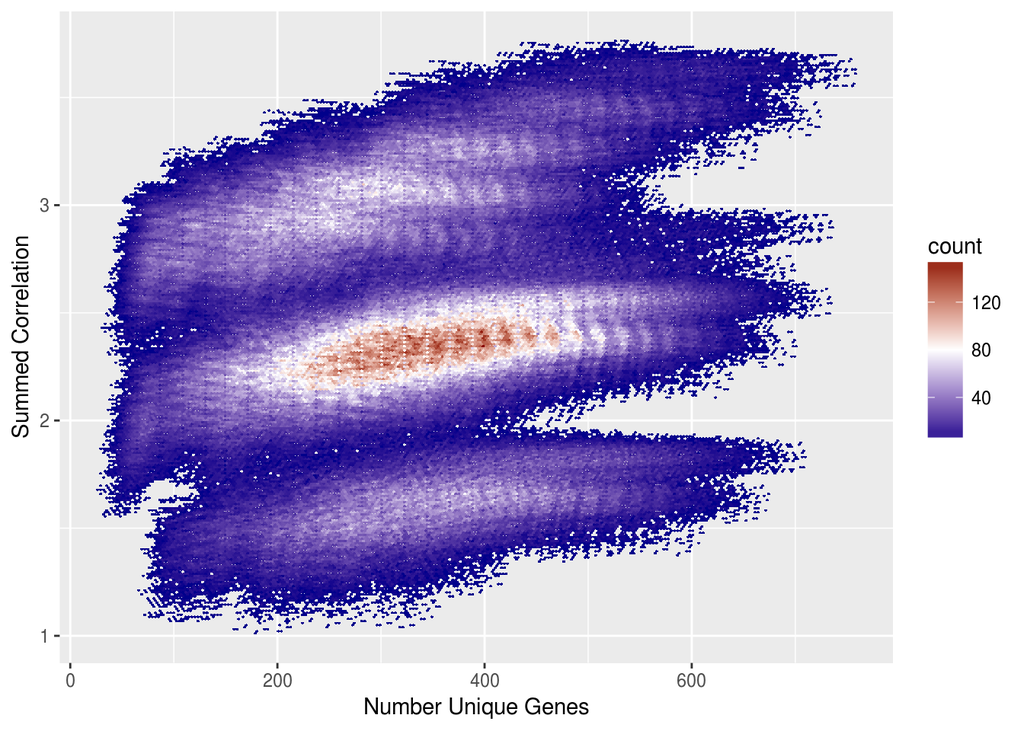

### 1 to 50 genes

[1] “The best pathway list between 1 and 50 is 50 with a summed correlation of 3.02327023379655”

| Pathway | Genes | Protein | ICBP.cor | TCGA.cor | ICBP.diff | TCGA.diff |
| --- | --- | --- | --- | --- | --- | --- |
| akt | 5 | Akt | 0.6168071 | -0.0511464 | 0.0411424 | -0.2432655 |
| akt | 5 | PDK1 | 0.6614509 | -0.0891008 | 0.0875369 | -0.3277670 |
| akt | 5 | PDK1_pS241 | 0.5944852 | 0.0165341 | 0.0595251 | -0.3207518 |
| bad | 15 | Akt | -0.0112704 | -0.0005623 | -0.4676660 | -0.1508035 |
| bad | 15 | PDK1 | 0.2478389 | 0.1888493 | -0.3567130 | -0.1238094 |
| bad | 15 | PDK1_pS241 | 0.2180764 | 0.2350648 | -0.2995951 | 0.0035171 |
| egfr | 10 | EGFR | 0.4975380 | 0.3548537 | 0.0271364 | -0.0017812 |
| egfr | 10 | EGFR_pY1068 | 0.4178794 | 0.0939790 | 0.0212277 | -0.0353075 |
| egfr | 10 | EGFR_pY1173 | NA | 0.1331719 | NA | -0.0220148 |
| her2 | 5 | HER2 | 0.9159645 | 0.3134173 | -0.0065653 | -0.0630429 |
| her2 | 5 | HER2_pY1248 | 0.9511982 | 0.3030885 | -0.0015319 | -0.0529551 |
| igf1r | 15 | IRS1 | NA | 0.3516127 | NA | 0.0278326 |
| igf1r | 15 | IGF1R | 0.3611993 | NA | 0.2755225 | NA |
| igf1r | 15 | PDK1 | 0.4725900 | 0.2677128 | -0.0967283 | -0.1030191 |
| igf1r | 15 | PDK1_pS241 | 0.4012474 | 0.3122586 | -0.1081081 | -0.0907584 |
| krasgv | 5 | EGFR | 0.1911588 | 0.1807791 | -0.2321917 | -0.3120602 |
| krasgv | 5 | EGFR_pY1068 | 0.1918153 | 0.0913609 | -0.1039501 | 0.0024104 |
| krasgv | 5 | EGFR_pY1173 | NA | 0.1050626 | NA | 0.0149734 |
| krasgv | 5 | MEK1 | NA | 0.0465197 | NA | -0.0692492 |
| raf | 10 | MEK1 | 0.0605099 | 0.0439229 | -0.2240945 | -0.2012081 |
| raf | 10 | PKC.alpha | 0.2918262 | 0.1146773 | -0.1748550 | -0.2812575 |
| raf | 10 | PKC.alpha_pS657 | 0.4067185 | 0.1042806 | -0.0553671 | -0.3105386 |

### 51 to 100 genes

[1] “The best pathway list between 51 and 100 is 100 with a summed correlation of 3.26166247218879”

| Pathway | Genes | Protein | ICBP.cor | TCGA.cor | ICBP.diff | TCGA.diff |
| --- | --- | --- | --- | --- | --- | --- |
| akt | 5 | Akt | 0.6168071 | -0.0511464 | 0.0411424 | -0.2432655 |
| akt | 5 | PDK1 | 0.6614509 | -0.0891008 | 0.0875369 | -0.3277670 |
| akt | 5 | PDK1_pS241 | 0.5944852 | 0.0165341 | 0.0595251 | -0.3207518 |
| bad | 20 | Akt | 0.0211183 | -0.1090624 | -0.4352774 | -0.2593036 |
| bad | 20 | PDK1 | 0.2585622 | -0.3477619 | -0.3459897 | -0.6604206 |
| bad | 20 | PDK1_pS241 | 0.2386476 | -0.3115458 | -0.2790240 | -0.5430935 |
| egfr | 10 | EGFR | 0.4975380 | 0.3548537 | 0.0271364 | -0.0017812 |
| egfr | 10 | EGFR_pY1068 | 0.4178794 | 0.0939790 | 0.0212277 | -0.0353075 |
| egfr | 10 | EGFR_pY1173 | NA | 0.1331719 | NA | -0.0220148 |
| her2 | 10 | HER2 | 0.9225298 | 0.3764602 | 0.0000000 | 0.0000000 |
| her2 | 10 | HER2_pY1248 | 0.9527301 | 0.3560436 | 0.0000000 | 0.0000000 |
| igf1r | 15 | IRS1 | NA | 0.3516127 | NA | 0.0278326 |
| igf1r | 15 | IGF1R | 0.3611993 | NA | 0.2755225 | NA |
| igf1r | 15 | PDK1 | 0.4725900 | 0.2677128 | -0.0967283 | -0.1030191 |
| igf1r | 15 | PDK1_pS241 | 0.4012474 | 0.3122586 | -0.1081081 | -0.0907584 |
| krasgv | 50 | EGFR | 0.3885545 | 0.1043801 | -0.0347959 | -0.3884592 |
| krasgv | 50 | EGFR_pY1068 | 0.3145858 | -0.0031642 | 0.0188204 | -0.0921147 |
| krasgv | 50 | EGFR_pY1173 | NA | 0.1025577 | NA | 0.0124686 |
| krasgv | 50 | MEK1 | NA | 0.0462040 | NA | -0.0695649 |
| raf | 25 | MEK1 | 0.3174308 | 0.0651606 | 0.0328263 | -0.1799703 |
| raf | 25 | PKC.alpha | 0.2522158 | 0.1424720 | -0.2144655 | -0.2534628 |
| raf | 25 | PKC.alpha_pS657 | 0.3485064 | 0.1329480 | -0.1135792 | -0.2818712 |

### 101 - 150 genes

[1] “The best pathway list between 101 and 150 is 141 with a summed correlation of 3.31381989276726”

| Pathway | Genes | Protein | ICBP.cor | TCGA.cor | ICBP.diff | TCGA.diff |
| --- | --- | --- | --- | --- | --- | --- |
| akt | 5 | Akt | 0.6168071 | -0.0511464 | 0.0411424 | -0.2432655 |
| akt | 5 | PDK1 | 0.6614509 | -0.0891008 | 0.0875369 | -0.3277670 |
| akt | 5 | PDK1_pS241 | 0.5944852 | 0.0165341 | 0.0595251 | -0.3207518 |
| bad | 20 | Akt | 0.0211183 | -0.1090624 | -0.4352774 | -0.2593036 |
| bad | 20 | PDK1 | 0.2585622 | -0.3477619 | -0.3459897 | -0.6604206 |
| bad | 20 | PDK1_pS241 | 0.2386476 | -0.3115458 | -0.2790240 | -0.5430935 |
| egfr | 10 | EGFR | 0.4975380 | 0.3548537 | 0.0271364 | -0.0017812 |
| egfr | 10 | EGFR_pY1068 | 0.4178794 | 0.0939790 | 0.0212277 | -0.0353075 |
| egfr | 10 | EGFR_pY1173 | NA | 0.1331719 | NA | -0.0220148 |
| her2 | 10 | HER2 | 0.9225298 | 0.3764602 | 0.0000000 | 0.0000000 |
| her2 | 10 | HER2_pY1248 | 0.9527301 | 0.3560436 | 0.0000000 | 0.0000000 |
| igf1r | 15 | IRS1 | NA | 0.3516127 | NA | 0.0278326 |
| igf1r | 15 | IGF1R | 0.3611993 | NA | 0.2755225 | NA |
| igf1r | 15 | PDK1 | 0.4725900 | 0.2677128 | -0.0967283 | -0.1030191 |
| igf1r | 15 | PDK1_pS241 | 0.4012474 | 0.3122586 | -0.1081081 | -0.0907584 |
| krasgv | 50 | EGFR | 0.3885545 | 0.1043801 | -0.0347959 | -0.3884592 |
| krasgv | 50 | EGFR_pY1068 | 0.3145858 | -0.0031642 | 0.0188204 | -0.0921147 |
| krasgv | 50 | EGFR_pY1173 | NA | 0.1025577 | NA | 0.0124686 |
| krasgv | 50 | MEK1 | NA | 0.0462040 | NA | -0.0695649 |
| raf | 75 | MEK1 | 0.3762994 | 0.0773367 | 0.0916949 | -0.1677942 |
| raf | 75 | PKC.alpha | 0.3202757 | 0.3435776 | -0.1464055 | -0.0523572 |
| raf | 75 | PKC.alpha_pS657 | 0.3780501 | 0.3333846 | -0.0840355 | -0.0814347 |

### 151 - 200 genes

[1] “The best pathway list between 151 and 200 is 200 with a summed correlation of 3.43640806798702”

| Pathway | Genes | Protein | ICBP.cor | TCGA.cor | ICBP.diff | TCGA.diff |
| --- | --- | --- | --- | --- | --- | --- |
| akt | 5 | Akt | 0.6168071 | -0.0511464 | 0.0411424 | -0.2432655 |
| akt | 5 | PDK1 | 0.6614509 | -0.0891008 | 0.0875369 | -0.3277670 |
| akt | 5 | PDK1_pS241 | 0.5944852 | 0.0165341 | 0.0595251 | -0.3207518 |
| bad | 125 | Akt | 0.2852610 | -0.1807524 | -0.1711347 | -0.3309936 |
| bad | 125 | PDK1 | 0.4119707 | -0.2636642 | -0.1925812 | -0.5763228 |
| bad | 125 | PDK1_pS241 | 0.3404092 | -0.3676472 | -0.1772623 | -0.5991950 |
| egfr | 20 | EGFR | 0.5181092 | 0.2079732 | 0.0477076 | -0.1486618 |
| egfr | 20 | EGFR_pY1068 | 0.4005909 | 0.0907600 | 0.0039392 | -0.0385266 |
| egfr | 20 | EGFR_pY1173 | NA | 0.1864142 | NA | 0.0312275 |
| her2 | 10 | HER2 | 0.9225298 | 0.3764602 | 0.0000000 | 0.0000000 |
| her2 | 10 | HER2_pY1248 | 0.9527301 | 0.3560436 | 0.0000000 | 0.0000000 |
| igf1r | 15 | IRS1 | NA | 0.3516127 | NA | 0.0278326 |
| igf1r | 15 | IGF1R | 0.3611993 | NA | 0.2755225 | NA |
| igf1r | 15 | PDK1 | 0.4725900 | 0.2677128 | -0.0967283 | -0.1030191 |
| igf1r | 15 | PDK1_pS241 | 0.4012474 | 0.3122586 | -0.1081081 | -0.0907584 |
| krasgv | 50 | EGFR | 0.3885545 | 0.1043801 | -0.0347959 | -0.3884592 |
| krasgv | 50 | EGFR_pY1068 | 0.3145858 | -0.0031642 | 0.0188204 | -0.0921147 |
| krasgv | 50 | EGFR_pY1173 | NA | 0.1025577 | NA | 0.0124686 |
| krasgv | 50 | MEK1 | NA | 0.0462040 | NA | -0.0695649 |
| raf | 25 | MEK1 | 0.3174308 | 0.0651606 | 0.0328263 | -0.1799703 |
| raf | 25 | PKC.alpha | 0.2522158 | 0.1424720 | -0.2144655 | -0.2534628 |
| raf | 25 | PKC.alpha_pS657 | 0.3485064 | 0.1329480 | -0.1135792 | -0.2818712 |

### 201 - 250 genes

[1] “The best pathway list between 201 and 250 is 237 with a summed correlation of 3.48856548856549”

| Pathway | Genes | Protein | ICBP.cor | TCGA.cor | ICBP.diff | TCGA.diff |
| --- | --- | --- | --- | --- | --- | --- |
| akt | 5 | Akt | 0.6168071 | -0.0511464 | 0.0411424 | -0.2432655 |
| akt | 5 | PDK1 | 0.6614509 | -0.0891008 | 0.0875369 | -0.3277670 |
| akt | 5 | PDK1_pS241 | 0.5944852 | 0.0165341 | 0.0595251 | -0.3207518 |
| bad | 125 | Akt | 0.2852610 | -0.1807524 | -0.1711347 | -0.3309936 |
| bad | 125 | PDK1 | 0.4119707 | -0.2636642 | -0.1925812 | -0.5763228 |
| bad | 125 | PDK1_pS241 | 0.3404092 | -0.3676472 | -0.1772623 | -0.5991950 |
| egfr | 20 | EGFR | 0.5181092 | 0.2079732 | 0.0477076 | -0.1486618 |
| egfr | 20 | EGFR_pY1068 | 0.4005909 | 0.0907600 | 0.0039392 | -0.0385266 |
| egfr | 20 | EGFR_pY1173 | NA | 0.1864142 | NA | 0.0312275 |
| her2 | 10 | HER2 | 0.9225298 | 0.3764602 | 0.0000000 | 0.0000000 |
| her2 | 10 | HER2_pY1248 | 0.9527301 | 0.3560436 | 0.0000000 | 0.0000000 |
| igf1r | 15 | IRS1 | NA | 0.3516127 | NA | 0.0278326 |
| igf1r | 15 | IGF1R | 0.3611993 | NA | 0.2755225 | NA |
| igf1r | 15 | PDK1 | 0.4725900 | 0.2677128 | -0.0967283 | -0.1030191 |
| igf1r | 15 | PDK1_pS241 | 0.4012474 | 0.3122586 | -0.1081081 | -0.0907584 |
| krasgv | 50 | EGFR | 0.3885545 | 0.1043801 | -0.0347959 | -0.3884592 |
| krasgv | 50 | EGFR_pY1068 | 0.3145858 | -0.0031642 | 0.0188204 | -0.0921147 |
| krasgv | 50 | EGFR_pY1173 | NA | 0.1025577 | NA | 0.0124686 |
| krasgv | 50 | MEK1 | NA | 0.0462040 | NA | -0.0695649 |
| raf | 75 | MEK1 | 0.3762994 | 0.0773367 | 0.0916949 | -0.1677942 |
| raf | 75 | PKC.alpha | 0.3202757 | 0.3435776 | -0.1464055 | -0.0523572 |
| raf | 75 | PKC.alpha_pS657 | 0.3780501 | 0.3333846 | -0.0840355 | -0.0814347 |

### 251 - 300 genes

[1] “The best pathway list between 251 and 300 is 296 with a summed correlation of 3.52252252252252”

| Pathway | Genes | Protein | ICBP.cor | TCGA.cor | ICBP.diff | TCGA.diff |
| --- | --- | --- | --- | --- | --- | --- |
| akt | 5 | Akt | 0.6168071 | -0.0511464 | 0.0411424 | -0.2432655 |
| akt | 5 | PDK1 | 0.6614509 | -0.0891008 | 0.0875369 | -0.3277670 |
| akt | 5 | PDK1_pS241 | 0.5944852 | 0.0165341 | 0.0595251 | -0.3207518 |
| bad | 125 | Akt | 0.2852610 | -0.1807524 | -0.1711347 | -0.3309936 |
| bad | 125 | PDK1 | 0.4119707 | -0.2636642 | -0.1925812 | -0.5763228 |
| bad | 125 | PDK1_pS241 | 0.3404092 | -0.3676472 | -0.1772623 | -0.5991950 |
| egfr | 10 | EGFR | 0.4975380 | 0.3548537 | 0.0271364 | -0.0017812 |
| egfr | 10 | EGFR_pY1068 | 0.4178794 | 0.0939790 | 0.0212277 | -0.0353075 |
| egfr | 10 | EGFR_pY1173 | NA | 0.1331719 | NA | -0.0220148 |
| her2 | 10 | HER2 | 0.9225298 | 0.3764602 | 0.0000000 | 0.0000000 |
| her2 | 10 | HER2_pY1248 | 0.9527301 | 0.3560436 | 0.0000000 | 0.0000000 |
| igf1r | 15 | IRS1 | NA | 0.3516127 | NA | 0.0278326 |
| igf1r | 15 | IGF1R | 0.3611993 | NA | 0.2755225 | NA |
| igf1r | 15 | PDK1 | 0.4725900 | 0.2677128 | -0.0967283 | -0.1030191 |
| igf1r | 15 | PDK1_pS241 | 0.4012474 | 0.3122586 | -0.1081081 | -0.0907584 |
| krasgv | 50 | EGFR | 0.3885545 | 0.1043801 | -0.0347959 | -0.3884592 |
| krasgv | 50 | EGFR_pY1068 | 0.3145858 | -0.0031642 | 0.0188204 | -0.0921147 |
| krasgv | 50 | EGFR_pY1173 | NA | 0.1025577 | NA | 0.0124686 |
| krasgv | 50 | MEK1 | NA | 0.0462040 | NA | -0.0695649 |
| raf | 150 | MEK1 | 0.3524456 | 0.1054433 | 0.0678411 | -0.1396876 |
| raf | 150 | PKC.alpha | 0.3990590 | 0.3582092 | -0.0676223 | -0.0377256 |
| raf | 150 | PKC.alpha_pS657 | 0.4299157 | 0.3492376 | -0.0321698 | -0.0655817 |

### 301 - 400 genes

[1] “The best pathway list between 301 and 400 is 358 with a summed correlation of 3.66889156362841”

| Pathway | Genes | Protein | ICBP.cor | TCGA.cor | ICBP.diff | TCGA.diff |
| --- | --- | --- | --- | --- | --- | --- |
| akt | 5 | Akt | 0.6168071 | -0.0511464 | 0.0411424 | -0.2432655 |
| akt | 5 | PDK1 | 0.6614509 | -0.0891008 | 0.0875369 | -0.3277670 |
| akt | 5 | PDK1_pS241 | 0.5944852 | 0.0165341 | 0.0595251 | -0.3207518 |
| bad | 250 | Akt | 0.4563957 | 0.1502412 | 0.0000000 | 0.0000000 |
| bad | 250 | PDK1 | 0.6045519 | 0.3126587 | 0.0000000 | 0.0000000 |
| bad | 250 | PDK1_pS241 | 0.5176715 | 0.2315477 | 0.0000000 | 0.0000000 |
| egfr | 20 | EGFR | 0.5181092 | 0.2079732 | 0.0477076 | -0.1486618 |
| egfr | 20 | EGFR_pY1068 | 0.4005909 | 0.0907600 | 0.0039392 | -0.0385266 |
| egfr | 20 | EGFR_pY1173 | NA | 0.1864142 | NA | 0.0312275 |
| her2 | 10 | HER2 | 0.9225298 | 0.3764602 | 0.0000000 | 0.0000000 |
| her2 | 10 | HER2_pY1248 | 0.9527301 | 0.3560436 | 0.0000000 | 0.0000000 |
| igf1r | 15 | IRS1 | NA | 0.3516127 | NA | 0.0278326 |
| igf1r | 15 | IGF1R | 0.3611993 | NA | 0.2755225 | NA |
| igf1r | 15 | PDK1 | 0.4725900 | 0.2677128 | -0.0967283 | -0.1030191 |
| igf1r | 15 | PDK1_pS241 | 0.4012474 | 0.3122586 | -0.1081081 | -0.0907584 |
| krasgv | 50 | EGFR | 0.3885545 | 0.1043801 | -0.0347959 | -0.3884592 |
| krasgv | 50 | EGFR_pY1068 | 0.3145858 | -0.0031642 | 0.0188204 | -0.0921147 |
| krasgv | 50 | EGFR_pY1173 | NA | 0.1025577 | NA | 0.0124686 |
| krasgv | 50 | MEK1 | NA | 0.0462040 | NA | -0.0695649 |
| raf | 75 | MEK1 | 0.3762994 | 0.0773367 | 0.0916949 | -0.1677942 |
| raf | 75 | PKC.alpha | 0.3202757 | 0.3435776 | -0.1464055 | -0.0523572 |
| raf | 75 | PKC.alpha_pS657 | 0.3780501 | 0.3333846 | -0.0840355 | -0.0814347 |

### 401 - 500 genes

[1] “The best pathway list between 401 and 500 is 499 with a summed correlation of 3.75737681000839”

| Pathway | Genes | Protein | ICBP.cor | TCGA.cor | ICBP.diff | TCGA.diff |
| --- | --- | --- | --- | --- | --- | --- |
| akt | 5 | Akt | 0.6168071 | -0.0511464 | 0.0411424 | -0.2432655 |
| akt | 5 | PDK1 | 0.6614509 | -0.0891008 | 0.0875369 | -0.3277670 |
| akt | 5 | PDK1_pS241 | 0.5944852 | 0.0165341 | 0.0595251 | -0.3207518 |
| bad | 250 | Akt | 0.4563957 | 0.1502412 | 0.0000000 | 0.0000000 |
| bad | 250 | PDK1 | 0.6045519 | 0.3126587 | 0.0000000 | 0.0000000 |
| bad | 250 | PDK1_pS241 | 0.5176715 | 0.2315477 | 0.0000000 | 0.0000000 |
| egfr | 20 | EGFR | 0.5181092 | 0.2079732 | 0.0477076 | -0.1486618 |
| egfr | 20 | EGFR_pY1068 | 0.4005909 | 0.0907600 | 0.0039392 | -0.0385266 |
| egfr | 20 | EGFR_pY1173 | NA | 0.1864142 | NA | 0.0312275 |
| her2 | 10 | HER2 | 0.9225298 | 0.3764602 | 0.0000000 | 0.0000000 |
| her2 | 10 | HER2_pY1248 | 0.9527301 | 0.3560436 | 0.0000000 | 0.0000000 |
| igf1r | 15 | IRS1 | NA | 0.3516127 | NA | 0.0278326 |
| igf1r | 15 | IGF1R | 0.3611993 | NA | 0.2755225 | NA |
| igf1r | 15 | PDK1 | 0.4725900 | 0.2677128 | -0.0967283 | -0.1030191 |
| igf1r | 15 | PDK1_pS241 | 0.4012474 | 0.3122586 | -0.1081081 | -0.0907584 |
| krasgv | 150 | EGFR | 0.3988401 | 0.4879869 | -0.0245103 | -0.0048524 |
| krasgv | 150 | EGFR_pY1068 | 0.3108655 | 0.0935103 | 0.0151001 | 0.0045598 |
| krasgv | 150 | EGFR_pY1173 | NA | 0.0887196 | NA | -0.0013696 |
| krasgv | 150 | MEK1 | NA | 0.0990456 | NA | -0.0167232 |
| raf | 175 | MEK1 | 0.3474122 | 0.0943705 | 0.0628077 | -0.1507605 |
| raf | 175 | PKC.alpha | 0.4802495 | 0.3556985 | 0.0135682 | -0.0402362 |
| raf | 175 | PKC.alpha_pS657 | 0.5025714 | 0.3444559 | 0.0404858 | -0.0703633 |

### 501 - 600 genes

[1] “The best pathway list between 501 and 600 is 534 with a summed correlation of 3.76208191997666”

| Pathway | Genes | Protein | ICBP.cor | TCGA.cor | ICBP.diff | TCGA.diff |
| --- | --- | --- | --- | --- | --- | --- |
| akt | 5 | Akt | 0.6168071 | -0.0511464 | 0.0411424 | -0.2432655 |
| akt | 5 | PDK1 | 0.6614509 | -0.0891008 | 0.0875369 | -0.3277670 |
| akt | 5 | PDK1_pS241 | 0.5944852 | 0.0165341 | 0.0595251 | -0.3207518 |
| bad | 250 | Akt | 0.4563957 | 0.1502412 | 0.0000000 | 0.0000000 |
| bad | 250 | PDK1 | 0.6045519 | 0.3126587 | 0.0000000 | 0.0000000 |
| bad | 250 | PDK1_pS241 | 0.5176715 | 0.2315477 | 0.0000000 | 0.0000000 |
| egfr | 20 | EGFR | 0.5181092 | 0.2079732 | 0.0477076 | -0.1486618 |
| egfr | 20 | EGFR_pY1068 | 0.4005909 | 0.0907600 | 0.0039392 | -0.0385266 |
| egfr | 20 | EGFR_pY1173 | NA | 0.1864142 | NA | 0.0312275 |
| her2 | 10 | HER2 | 0.9225298 | 0.3764602 | 0.0000000 | 0.0000000 |
| her2 | 10 | HER2_pY1248 | 0.9527301 | 0.3560436 | 0.0000000 | 0.0000000 |
| igf1r | 15 | IRS1 | NA | 0.3516127 | NA | 0.0278326 |
| igf1r | 15 | IGF1R | 0.3611993 | NA | 0.2755225 | NA |
| igf1r | 15 | PDK1 | 0.4725900 | 0.2677128 | -0.0967283 | -0.1030191 |
| igf1r | 15 | PDK1_pS241 | 0.4012474 | 0.3122586 | -0.1081081 | -0.0907584 |
| krasgv | 200 | EGFR | 0.4233505 | 0.4928393 | 0.0000000 | 0.0000000 |
| krasgv | 200 | EGFR_pY1068 | 0.2957654 | 0.0889505 | 0.0000000 | 0.0000000 |
| krasgv | 200 | EGFR_pY1173 | NA | 0.0900892 | NA | 0.0000000 |
| krasgv | 200 | MEK1 | NA | 0.1157688 | NA | 0.0000000 |
| raf | 175 | MEK1 | 0.3474122 | 0.0943705 | 0.0628077 | -0.1507605 |
| raf | 175 | PKC.alpha | 0.4802495 | 0.3556985 | 0.0135682 | -0.0402362 |
| raf | 175 | PKC.alpha_pS657 | 0.5025714 | 0.3444559 | 0.0404858 | -0.0703633 |

### 601 - 700 genes

[1] “The best pathway list between 601 and 700 is 633 with a summed correlation of 3.72356567093409”

| Pathway | Genes | Protein | ICBP.cor | TCGA.cor | ICBP.diff | TCGA.diff |
| --- | --- | --- | --- | --- | --- | --- |
| akt | 5 | Akt | 0.6168071 | -0.0511464 | 0.0411424 | -0.2432655 |
| akt | 5 | PDK1 | 0.6614509 | -0.0891008 | 0.0875369 | -0.3277670 |
| akt | 5 | PDK1_pS241 | 0.5944852 | 0.0165341 | 0.0595251 | -0.3207518 |
| bad | 250 | Akt | 0.4563957 | 0.1502412 | 0.0000000 | 0.0000000 |
| bad | 250 | PDK1 | 0.6045519 | 0.3126587 | 0.0000000 | 0.0000000 |
| bad | 250 | PDK1_pS241 | 0.5176715 | 0.2315477 | 0.0000000 | 0.0000000 |
| egfr | 20 | EGFR | 0.5181092 | 0.2079732 | 0.0477076 | -0.1486618 |
| egfr | 20 | EGFR_pY1068 | 0.4005909 | 0.0907600 | 0.0039392 | -0.0385266 |
| egfr | 20 | EGFR_pY1173 | NA | 0.1864142 | NA | 0.0312275 |
| her2 | 10 | HER2 | 0.9225298 | 0.3764602 | 0.0000000 | 0.0000000 |
| her2 | 10 | HER2_pY1248 | 0.9527301 | 0.3560436 | 0.0000000 | 0.0000000 |
| igf1r | 15 | IRS1 | NA | 0.3516127 | NA | 0.0278326 |
| igf1r | 15 | IGF1R | 0.3611993 | NA | 0.2755225 | NA |
| igf1r | 15 | PDK1 | 0.4725900 | 0.2677128 | -0.0967283 | -0.1030191 |
| igf1r | 15 | PDK1_pS241 | 0.4012474 | 0.3122586 | -0.1081081 | -0.0907584 |
| krasgv | 200 | EGFR | 0.4233505 | 0.4928393 | 0.0000000 | 0.0000000 |
| krasgv | 200 | EGFR_pY1068 | 0.2957654 | 0.0889505 | 0.0000000 | 0.0000000 |
| krasgv | 200 | EGFR_pY1173 | NA | 0.0900892 | NA | 0.0000000 |
| krasgv | 200 | MEK1 | NA | 0.1157688 | NA | 0.0000000 |
| raf | 300 | MEK1 | 0.2710362 | 0.1288930 | -0.0135682 | -0.1162379 |
| raf | 300 | PKC.alpha | 0.4743407 | 0.3694637 | 0.0076595 | -0.0264711 |
| raf | 300 | PKC.alpha_pS657 | 0.4693074 | 0.3670136 | 0.0072218 | -0.0478057 |